# Project: Investigate a Dataset (No Show-Up Data In Brasil!)

1) Data Gathering 2) Wragling 3) Explore 4) Conclusions

### 1 - Data Gathering // No Show Up Data In Brasil Has Been Selected For Analysis

### 2 - Data Wragling // Lets Start !

```python
import pandas as pd
import numpy as np
import matplotlib.pyplot as plt
import seaborn as sns

df = pd.read_csv("C:/Users/ASUS PC/Desktop/UDACITY/Python Calismalar/Intro To Data - No Show Appoinments/noshow.csv")
```

```python
df.head(10) #looking first items in dataset
```

|  | PatientId | AppointmentID | Gender | ScheduledDay | AppointmentDay | Age | Neighbourhood | Scholarship | Hipertension | Diabetes | Alcoholism | Handcap | SMS_received | No-show |
| --- | --- | --- | --- | --- | --- | --- | --- | --- | --- | --- | --- | --- | --- | --- |
| 0 | 2.987250e+13 | 5642903 | F | 2016-04-29T18:38:08Z | 2016-04-29T00:00:00Z | 62 | JARDIM DA PENHA | 0 | 1 | 0 | 0 | 0 | 0 | No |
| 1 | 5.589978e+14 | 5642503 | M | 2016-04-29T16:08:27Z | 2016-04-29T00:00:00Z | 56 | JARDIM DA PENHA | 0 | 0 | 0 | 0 | 0 | 0 | No |
| 2 | 4.262962e+12 | 5642549 | F | 2016-04-29T16:19:04Z | 2016-04-29T00:00:00Z | 62 | MATA DA PRAIA | 0 | 0 | 0 | 0 | 0 | 0 | No |
| 3 | 8.679512e+11 | 5642828 | F | 2016-04-29T17:29:31Z | 2016-04-29T00:00:00Z | 8 | PONTAL DE CAMBURI | 0 | 0 | 0 | 0 | 0 | 0 | No |
| 4 | 8.841186e+12 | 5642494 | F | 2016-04-29T16:07:23Z | 2016-04-29T00:00:00Z | 56 | JARDIM DA PENHA | 0 | 1 | 1 | 0 | 0 | 0 | No |
| 5 | 9.598513e+13 | 5626772 | F | 2016-04-27T08:36:51Z | 2016-04-29T00:00:00Z | 76 | REPÚBLICA | 0 | 1 | 0 | 0 | 0 | 0 | No |
| 6 | 7.336882e+14 | 5630279 | F | 2016-04-27T15:05:12Z | 2016-04-29T00:00:00Z | 23 | GOIABEIRAS | 0 | 0 | 0 | 0 | 0 | 0 | Yes |
| 7 | 3.449833e+12 | 5630575 | F | 2016-04-27T15:39:58Z | 2016-04-29T00:00:00Z | 39 | GOIABEIRAS | 0 | 0 | 0 | 0 | 0 | 0 | Yes |
| 8 | 5.639473e+13 | 5638447 | F | 2016-04-29T08:02:16Z | 2016-04-29T00:00:00Z | 21 | ANDORINHAS | 0 | 0 | 0 | 0 | 0 | 0 | No |
| 9 | 7.812456e+13 | 5629123 | F | 2016-04-27T12:48:25Z | 2016-04-29T00:00:00Z | 19 | CONQUISTA | 0 | 0 | 0 | 0 | 0 | 0 | No |

```python
df.tail(10) #looking last items in dataset
```

|  | PatientId | AppointmentID | Gender | ScheduledDay | AppointmentDay | Age | Neighbourhood | Scholarship | Hipertension | Diabetes | Alcoholism | Handcap | SMS_received | No-show |
| --- | --- | --- | --- | --- | --- | --- | --- | --- | --- | --- | --- | --- | --- | --- |
| 110517 | 5.574942e+12 | 5780122 | F | 2016-06-07T07:38:34Z | 2016-06-07T00:00:00Z | 19 | MARIA ORTIZ | 0 | 0 | 0 | 0 | 0 | 0 | No |
| 110518 | 7.263315e+13 | 5630375 | F | 2016-04-27T15:15:06Z | 2016-06-07T00:00:00Z | 50 | MARIA ORTIZ | 0 | 0 | 0 | 0 | 0 | 1 | No |
| 110519 | 6.542388e+13 | 5630447 | F | 2016-04-27T15:23:14Z | 2016-06-07T00:00:00Z | 22 | MARIA ORTIZ | 0 | 0 | 0 | 0 | 0 | 1 | No |
| 110520 | 9.969977e+14 | 5650534 | F | 2016-05-03T07:51:47Z | 2016-06-07T00:00:00Z | 42 | MARIA ORTIZ | 0 | 0 | 0 | 0 | 0 | 1 | No |
| 110521 | 3.635534e+13 | 5651072 | F | 2016-05-03T08:23:40Z | 2016-06-07T00:00:00Z | 53 | MARIA ORTIZ | 0 | 0 | 0 | 0 | 0 | 1 | No |
| 110522 | 2.572134e+12 | 5651768 | F | 2016-05-03T09:15:35Z | 2016-06-07T00:00:00Z | 56 | MARIA ORTIZ | 0 | 0 | 0 | 0 | 0 | 1 | No |
| 110523 | 3.596266e+12 | 5650093 | F | 2016-05-03T07:27:33Z | 2016-06-07T00:00:00Z | 51 | MARIA ORTIZ | 0 | 0 | 0 | 0 | 0 | 1 | No |
| 110524 | 1.557663e+13 | 5630692 | F | 2016-04-27T16:03:52Z | 2016-06-07T00:00:00Z | 21 | MARIA ORTIZ | 0 | 0 | 0 | 0 | 0 | 1 | No |
| 110525 | 9.213493e+13 | 5630323 | F | 2016-04-27T15:09:23Z | 2016-06-07T00:00:00Z | 38 | MARIA ORTIZ | 0 | 0 | 0 | 0 | 0 | 1 | No |
| 110526 | 3.775115e+14 | 5629448 | F | 2016-04-27T13:30:56Z | 2016-06-07T00:00:00Z | 54 | MARIA ORTIZ | 0 | 0 | 0 | 0 | 0 | 1 | No |

```python
df.shape # learning dimensions of dataset roughly
```

```
(110527, 14)
```

```python
df.info() #getting info about dataset
```

```
<class 'pandas.core.frame.DataFrame'>
RangeIndex: 110527 entries, 0 to 110526
Data columns (total 14 columns):
PatientId         110527 non-null float64
AppointmentID     110527 non-null int64
Gender            110527 non-null object
ScheduledDay      110527 non-null object
AppointmentDay    110527 non-null object
Age               110527 non-null int64
Neighbourhood     110527 non-null object
Scholarship       110527 non-null int64
Hipertension      110527 non-null int64
Diabetes          110527 non-null int64
Alcoholism        110527 non-null int64
Handcap           110527 non-null int64
SMS_received      110527 non-null int64
No-show           110527 non-null object
dtypes: float64(1), int64(8), object(5)
memory usage: 9.7+ MB
```

### Data Wragling - First Insights

#### 2.1 - ScheduledDay & AppointmentDay names can be changed like "scheduled_day" & "appointment_day"

#### 2.2 - All column names can be lower and there should be "_" instead of whitepace or "-" for better usage

#### 2.3 - ScheduledDay & AppointmentDay seems to have redundant words like 'Z' and 'T', clear them & check if there is any other strings

#### 2.4 - After deletion of strings in ScheduledDay & AppointmentDay check if they can convert to datetime objects to better usage

Solution --> It seems there are only 'Z' and 'T' exist (see below head & tail actions) .Delete only 'Z' & 'T' later on convert them to datatime , if there is no error this means there is no any other strings If there is an error find out the other string

#### 2.5 - Non-Null & duplicate status should be checked

```python
df = df.rename(columns={"ScheduledDay": "scheduled_day"}) #change names to be easy for further
df = df.rename(columns={"AppointmentDay": "appointment_day"})
```

```python
df.head(1) #check if changes are OK --> DONE !
```

|  | PatientId | AppointmentID | Gender | scheduled_day | appointment_day | Age | Neighbourhood | Scholarship | Hipertension | Diabetes | Alcoholism | Handcap | SMS_received | No-show |
| --- | --- | --- | --- | --- | --- | --- | --- | --- | --- | --- | --- | --- | --- | --- |
| 0 | 2.987250e+13 | 5642903 | F | 2016-04-29T18:38:08Z | 2016-04-29T00:00:00Z | 62 | JARDIM DA PENHA | 0 | 1 | 0 | 0 | 0 | 0 | No |

```python
df.rename(columns=lambda x: x.strip().lower().replace("-","_"), inplace=True) #all column names have same style
```

```python
df.head(1) #check if changes have been made --> DONE!
```

|  | patientid | appointmentid | gender | scheduled_day | appointment_day | age | neighbourhood | scholarship | hipertension | diabetes | alcoholism | handcap | sms_received | no_show |
| --- | --- | --- | --- | --- | --- | --- | --- | --- | --- | --- | --- | --- | --- | --- |
| 0 | 2.987250e+13 | 5642903 | F | 2016-04-29T18:38:08Z | 2016-04-29T00:00:00Z | 62 | JARDIM DA PENHA | 0 | 1 | 0 | 0 | 0 | 0 | No |

```python
df.head(25)
```

|  | patientid | appointmentid | gender | scheduled_day | appointment_day | age | neighbourhood | scholarship | hipertension | diabetes | alcoholism | handcap | sms_received | no_show |
| --- | --- | --- | --- | --- | --- | --- | --- | --- | --- | --- | --- | --- | --- | --- |
| 0 | 2.987250e+13 | 5642903 | F | 2016-04-29T18:38:08Z | 2016-04-29T00:00:00Z | 62 | JARDIM DA PENHA | 0 | 1 | 0 | 0 | 0 | 0 | No |
| 1 | 5.589978e+14 | 5642503 | M | 2016-04-29T16:08:27Z | 2016-04-29T00:00:00Z | 56 | JARDIM DA PENHA | 0 | 0 | 0 | 0 | 0 | 0 | No |
| 2 | 4.262962e+12 | 5642549 | F | 2016-04-29T16:19:04Z | 2016-04-29T00:00:00Z | 62 | MATA DA PRAIA | 0 | 0 | 0 | 0 | 0 | 0 | No |
| 3 | 8.679512e+11 | 5642828 | F | 2016-04-29T17:29:31Z | 2016-04-29T00:00:00Z | 8 | PONTAL DE CAMBURI | 0 | 0 | 0 | 0 | 0 | 0 | No |
| 4 | 8.841186e+12 | 5642494 | F | 2016-04-29T16:07:23Z | 2016-04-29T00:00:00Z | 56 | JARDIM DA PENHA | 0 | 1 | 1 | 0 | 0 | 0 | No |
| 5 | 9.598513e+13 | 5626772 | F | 2016-04-27T08:36:51Z | 2016-04-29T00:00:00Z | 76 | REPÚBLICA | 0 | 1 | 0 | 0 | 0 | 0 | No |
| 6 | 7.336882e+14 | 5630279 | F | 2016-04-27T15:05:12Z | 2016-04-29T00:00:00Z | 23 | GOIABEIRAS | 0 | 0 | 0 | 0 | 0 | 0 | Yes |
| 7 | 3.449833e+12 | 5630575 | F | 2016-04-27T15:39:58Z | 2016-04-29T00:00:00Z | 39 | GOIABEIRAS | 0 | 0 | 0 | 0 | 0 | 0 | Yes |
| 8 | 5.639473e+13 | 5638447 | F | 2016-04-29T08:02:16Z | 2016-04-29T00:00:00Z | 21 | ANDORINHAS | 0 | 0 | 0 | 0 | 0 | 0 | No |
| 9 | 7.812456e+13 | 5629123 | F | 2016-04-27T12:48:25Z | 2016-04-29T00:00:00Z | 19 | CONQUISTA | 0 | 0 | 0 | 0 | 0 | 0 | No |
| 10 | 7.345362e+14 | 5630213 | F | 2016-04-27T14:58:11Z | 2016-04-29T00:00:00Z | 30 | NOVA PALESTINA | 0 | 0 | 0 | 0 | 0 | 0 | No |
| 11 | 7.542951e+12 | 5620163 | M | 2016-04-26T08:44:12Z | 2016-04-29T00:00:00Z | 29 | NOVA PALESTINA | 0 | 0 | 0 | 0 | 0 | 1 | Yes |
| 12 | 5.666548e+14 | 5634718 | F | 2016-04-28T11:33:51Z | 2016-04-29T00:00:00Z | 22 | NOVA PALESTINA | 1 | 0 | 0 | 0 | 0 | 0 | No |
| 13 | 9.113946e+14 | 5636249 | M | 2016-04-28T14:52:07Z | 2016-04-29T00:00:00Z | 28 | NOVA PALESTINA | 0 | 0 | 0 | 0 | 0 | 0 | No |
| 14 | 9.988472e+13 | 5633951 | F | 2016-04-28T10:06:24Z | 2016-04-29T00:00:00Z | 54 | NOVA PALESTINA | 0 | 0 | 0 | 0 | 0 | 0 | No |
| 15 | 9.994839e+10 | 5620206 | F | 2016-04-26T08:47:27Z | 2016-04-29T00:00:00Z | 15 | NOVA PALESTINA | 0 | 0 | 0 | 0 | 0 | 1 | No |
| 16 | 8.457439e+13 | 5633121 | M | 2016-04-28T08:51:47Z | 2016-04-29T00:00:00Z | 50 | NOVA PALESTINA | 0 | 0 | 0 | 0 | 0 | 0 | No |
| 17 | 1.479497e+13 | 5633460 | F | 2016-04-28T09:28:57Z | 2016-04-29T00:00:00Z | 40 | CONQUISTA | 1 | 0 | 0 | 0 | 0 | 0 | Yes |
| 18 | 1.713538e+13 | 5621836 | F | 2016-04-26T10:54:18Z | 2016-04-29T00:00:00Z | 30 | NOVA PALESTINA | 1 | 0 | 0 | 0 | 0 | 1 | No |
| 19 | 7.223289e+12 | 5640433 | F | 2016-04-29T10:43:14Z | 2016-04-29T00:00:00Z | 46 | DA PENHA | 0 | 0 | 0 | 0 | 0 | 0 | No |
| 20 | 6.222575e+14 | 5626083 | F | 2016-04-27T07:51:14Z | 2016-04-29T00:00:00Z | 30 | NOVA PALESTINA | 0 | 0 | 0 | 0 | 0 | 0 | Yes |
| 21 | 1.215484e+13 | 5628338 | F | 2016-04-27T10:50:45Z | 2016-04-29T00:00:00Z | 4 | CONQUISTA | 0 | 0 | 0 | 0 | 0 | 0 | Yes |
| 22 | 8.632298e+14 | 5616091 | M | 2016-04-25T13:29:16Z | 2016-04-29T00:00:00Z | 13 | CONQUISTA | 0 | 0 | 0 | 0 | 0 | 1 | Yes |
| 23 | 2.137540e+14 | 5634142 | F | 2016-04-28T10:27:05Z | 2016-04-29T00:00:00Z | 46 | CONQUISTA | 0 | 0 | 0 | 0 | 0 | 0 | No |
| 24 | 8.734858e+12 | 5641780 | F | 2016-04-29T14:19:19Z | 2016-04-29T00:00:00Z | 65 | TABUAZEIRO | 0 | 0 | 0 | 0 | 0 | 0 | No |

```python
df.tail(25)
```

|  | patientid | appointmentid | gender | scheduled_day | appointment_day | age | neighbourhood | scholarship | hipertension | diabetes | alcoholism | handcap | sms_received | no_show |
| --- | --- | --- | --- | --- | --- | --- | --- | --- | --- | --- | --- | --- | --- | --- |
| 110502 | 7.316229e+14 | 5787937 | F | 2016-06-08T10:50:42Z | 2016-06-08T00:00:00Z | 22 | GOIABEIRAS | 0 | 0 | 0 | 0 | 0 | 0 | No |
| 110503 | 2.362182e+13 | 5759473 | F | 2016-06-01T13:00:36Z | 2016-06-01T00:00:00Z | 64 | SOLON BORGES | 0 | 0 | 0 | 0 | 0 | 0 | No |
| 110504 | 9.947983e+12 | 5788052 | F | 2016-06-08T11:06:21Z | 2016-06-08T00:00:00Z | 4 | MARIA ORTIZ | 0 | 0 | 0 | 0 | 0 | 0 | No |
| 110505 | 5.667344e+13 | 5758455 | F | 2016-06-01T10:45:50Z | 2016-06-01T00:00:00Z | 55 | MARIA ORTIZ | 0 | 0 | 0 | 0 | 0 | 0 | No |
| 110506 | 8.973883e+11 | 5758779 | M | 2016-06-01T11:09:20Z | 2016-06-01T00:00:00Z | 5 | MARIA ORTIZ | 0 | 0 | 0 | 0 | 0 | 0 | No |
| 110507 | 4.769462e+14 | 5786918 | F | 2016-06-08T09:04:18Z | 2016-06-08T00:00:00Z | 0 | MARIA ORTIZ | 0 | 0 | 0 | 0 | 0 | 0 | No |
| 110508 | 9.433654e+13 | 5757656 | F | 2016-06-01T09:41:00Z | 2016-06-01T00:00:00Z | 59 | MARIA ORTIZ | 0 | 0 | 0 | 0 | 0 | 0 | No |
| 110509 | 4.952968e+14 | 5786750 | M | 2016-06-08T08:50:51Z | 2016-06-08T00:00:00Z | 33 | MARIA ORTIZ | 0 | 0 | 0 | 0 | 0 | 0 | No |
| 110510 | 2.362182e+13 | 5757587 | F | 2016-06-01T09:35:48Z | 2016-06-01T00:00:00Z | 64 | SOLON BORGES | 0 | 0 | 0 | 0 | 0 | 0 | No |
| 110511 | 8.235996e+11 | 5786742 | F | 2016-06-08T08:50:20Z | 2016-06-08T00:00:00Z | 14 | MARIA ORTIZ | 0 | 0 | 0 | 0 | 0 | 0 | No |
| 110512 | 9.876246e+13 | 5786368 | F | 2016-06-08T08:20:01Z | 2016-06-08T00:00:00Z | 41 | MARIA ORTIZ | 0 | 0 | 0 | 0 | 0 | 0 | No |
| 110513 | 8.674778e+13 | 5785964 | M | 2016-06-08T07:52:55Z | 2016-06-08T00:00:00Z | 2 | ANTÔNIO HONÓRIO | 0 | 0 | 0 | 0 | 0 | 0 | No |
| 110514 | 2.695685e+12 | 5786567 | F | 2016-06-08T08:35:31Z | 2016-06-08T00:00:00Z | 58 | MARIA ORTIZ | 0 | 0 | 0 | 0 | 0 | 0 | No |
| 110515 | 6.456342e+14 | 5778621 | M | 2016-06-06T15:58:05Z | 2016-06-08T00:00:00Z | 33 | MARIA ORTIZ | 0 | 1 | 0 | 0 | 0 | 0 | Yes |
| 110516 | 6.923772e+13 | 5780205 | F | 2016-06-07T07:45:16Z | 2016-06-08T00:00:00Z | 37 | MARIA ORTIZ | 0 | 0 | 0 | 0 | 0 | 0 | Yes |
| 110517 | 5.574942e+12 | 5780122 | F | 2016-06-07T07:38:34Z | 2016-06-07T00:00:00Z | 19 | MARIA ORTIZ | 0 | 0 | 0 | 0 | 0 | 0 | No |
| 110518 | 7.263315e+13 | 5630375 | F | 2016-04-27T15:15:06Z | 2016-06-07T00:00:00Z | 50 | MARIA ORTIZ | 0 | 0 | 0 | 0 | 0 | 1 | No |
| 110519 | 6.542388e+13 | 5630447 | F | 2016-04-27T15:23:14Z | 2016-06-07T00:00:00Z | 22 | MARIA ORTIZ | 0 | 0 | 0 | 0 | 0 | 1 | No |
| 110520 | 9.969977e+14 | 5650534 | F | 2016-05-03T07:51:47Z | 2016-06-07T00:00:00Z | 42 | MARIA ORTIZ | 0 | 0 | 0 | 0 | 0 | 1 | No |
| 110521 | 3.635534e+13 | 5651072 | F | 2016-05-03T08:23:40Z | 2016-06-07T00:00:00Z | 53 | MARIA ORTIZ | 0 | 0 | 0 | 0 | 0 | 1 | No |
| 110522 | 2.572134e+12 | 5651768 | F | 2016-05-03T09:15:35Z | 2016-06-07T00:00:00Z | 56 | MARIA ORTIZ | 0 | 0 | 0 | 0 | 0 | 1 | No |
| 110523 | 3.596266e+12 | 5650093 | F | 2016-05-03T07:27:33Z | 2016-06-07T00:00:00Z | 51 | MARIA ORTIZ | 0 | 0 | 0 | 0 | 0 | 1 | No |
| 110524 | 1.557663e+13 | 5630692 | F | 2016-04-27T16:03:52Z | 2016-06-07T00:00:00Z | 21 | MARIA ORTIZ | 0 | 0 | 0 | 0 | 0 | 1 | No |
| 110525 | 9.213493e+13 | 5630323 | F | 2016-04-27T15:09:23Z | 2016-06-07T00:00:00Z | 38 | MARIA ORTIZ | 0 | 0 | 0 | 0 | 0 | 1 | No |
| 110526 | 3.775115e+14 | 5629448 | F | 2016-04-27T13:30:56Z | 2016-06-07T00:00:00Z | 54 | MARIA ORTIZ | 0 | 0 | 0 | 0 | 0 | 1 | No |

```python
df['scheduled_day'] = df['scheduled_day'].map(lambda x: x.strip("Z")) # string 'Z' excluded from columns
df['appointment_day'] = df['appointment_day'].map(lambda x: x.strip("Z"))
```

```python
 df.head(50) #check whether it has been done or not --> DONE!
```

|  | patientid | appointmentid | gender | scheduled_day | appointment_day | age | neighbourhood | scholarship | hipertension | diabetes | alcoholism | handcap | sms_received | no_show |
| --- | --- | --- | --- | --- | --- | --- | --- | --- | --- | --- | --- | --- | --- | --- |
| 0 | 2.987250e+13 | 5642903 | F | 2016-04-29T18:38:08 | 2016-04-29T00:00:00 | 62 | JARDIM DA PENHA | 0 | 1 | 0 | 0 | 0 | 0 | No |
| 1 | 5.589978e+14 | 5642503 | M | 2016-04-29T16:08:27 | 2016-04-29T00:00:00 | 56 | JARDIM DA PENHA | 0 | 0 | 0 | 0 | 0 | 0 | No |
| 2 | 4.262962e+12 | 5642549 | F | 2016-04-29T16:19:04 | 2016-04-29T00:00:00 | 62 | MATA DA PRAIA | 0 | 0 | 0 | 0 | 0 | 0 | No |
| 3 | 8.679512e+11 | 5642828 | F | 2016-04-29T17:29:31 | 2016-04-29T00:00:00 | 8 | PONTAL DE CAMBURI | 0 | 0 | 0 | 0 | 0 | 0 | No |
| 4 | 8.841186e+12 | 5642494 | F | 2016-04-29T16:07:23 | 2016-04-29T00:00:00 | 56 | JARDIM DA PENHA | 0 | 1 | 1 | 0 | 0 | 0 | No |
| 5 | 9.598513e+13 | 5626772 | F | 2016-04-27T08:36:51 | 2016-04-29T00:00:00 | 76 | REPÚBLICA | 0 | 1 | 0 | 0 | 0 | 0 | No |
| 6 | 7.336882e+14 | 5630279 | F | 2016-04-27T15:05:12 | 2016-04-29T00:00:00 | 23 | GOIABEIRAS | 0 | 0 | 0 | 0 | 0 | 0 | Yes |
| 7 | 3.449833e+12 | 5630575 | F | 2016-04-27T15:39:58 | 2016-04-29T00:00:00 | 39 | GOIABEIRAS | 0 | 0 | 0 | 0 | 0 | 0 | Yes |
| 8 | 5.639473e+13 | 5638447 | F | 2016-04-29T08:02:16 | 2016-04-29T00:00:00 | 21 | ANDORINHAS | 0 | 0 | 0 | 0 | 0 | 0 | No |
| 9 | 7.812456e+13 | 5629123 | F | 2016-04-27T12:48:25 | 2016-04-29T00:00:00 | 19 | CONQUISTA | 0 | 0 | 0 | 0 | 0 | 0 | No |
| 10 | 7.345362e+14 | 5630213 | F | 2016-04-27T14:58:11 | 2016-04-29T00:00:00 | 30 | NOVA PALESTINA | 0 | 0 | 0 | 0 | 0 | 0 | No |
| 11 | 7.542951e+12 | 5620163 | M | 2016-04-26T08:44:12 | 2016-04-29T00:00:00 | 29 | NOVA PALESTINA | 0 | 0 | 0 | 0 | 0 | 1 | Yes |
| 12 | 5.666548e+14 | 5634718 | F | 2016-04-28T11:33:51 | 2016-04-29T00:00:00 | 22 | NOVA PALESTINA | 1 | 0 | 0 | 0 | 0 | 0 | No |
| 13 | 9.113946e+14 | 5636249 | M | 2016-04-28T14:52:07 | 2016-04-29T00:00:00 | 28 | NOVA PALESTINA | 0 | 0 | 0 | 0 | 0 | 0 | No |
| 14 | 9.988472e+13 | 5633951 | F | 2016-04-28T10:06:24 | 2016-04-29T00:00:00 | 54 | NOVA PALESTINA | 0 | 0 | 0 | 0 | 0 | 0 | No |
| 15 | 9.994839e+10 | 5620206 | F | 2016-04-26T08:47:27 | 2016-04-29T00:00:00 | 15 | NOVA PALESTINA | 0 | 0 | 0 | 0 | 0 | 1 | No |
| 16 | 8.457439e+13 | 5633121 | M | 2016-04-28T08:51:47 | 2016-04-29T00:00:00 | 50 | NOVA PALESTINA | 0 | 0 | 0 | 0 | 0 | 0 | No |
| 17 | 1.479497e+13 | 5633460 | F | 2016-04-28T09:28:57 | 2016-04-29T00:00:00 | 40 | CONQUISTA | 1 | 0 | 0 | 0 | 0 | 0 | Yes |
| 18 | 1.713538e+13 | 5621836 | F | 2016-04-26T10:54:18 | 2016-04-29T00:00:00 | 30 | NOVA PALESTINA | 1 | 0 | 0 | 0 | 0 | 1 | No |
| 19 | 7.223289e+12 | 5640433 | F | 2016-04-29T10:43:14 | 2016-04-29T00:00:00 | 46 | DA PENHA | 0 | 0 | 0 | 0 | 0 | 0 | No |
| 20 | 6.222575e+14 | 5626083 | F | 2016-04-27T07:51:14 | 2016-04-29T00:00:00 | 30 | NOVA PALESTINA | 0 | 0 | 0 | 0 | 0 | 0 | Yes |
| 21 | 1.215484e+13 | 5628338 | F | 2016-04-27T10:50:45 | 2016-04-29T00:00:00 | 4 | CONQUISTA | 0 | 0 | 0 | 0 | 0 | 0 | Yes |
| 22 | 8.632298e+14 | 5616091 | M | 2016-04-25T13:29:16 | 2016-04-29T00:00:00 | 13 | CONQUISTA | 0 | 0 | 0 | 0 | 0 | 1 | Yes |
| 23 | 2.137540e+14 | 5634142 | F | 2016-04-28T10:27:05 | 2016-04-29T00:00:00 | 46 | CONQUISTA | 0 | 0 | 0 | 0 | 0 | 0 | No |
| 24 | 8.734858e+12 | 5641780 | F | 2016-04-29T14:19:19 | 2016-04-29T00:00:00 | 65 | TABUAZEIRO | 0 | 0 | 0 | 0 | 0 | 0 | No |
| 25 | 5.819370e+12 | 5624020 | M | 2016-04-26T15:04:17 | 2016-04-29T00:00:00 | 46 | CONQUISTA | 0 | 1 | 0 | 0 | 0 | 1 | No |
| 26 | 2.578785e+10 | 5641781 | F | 2016-04-29T14:19:42 | 2016-04-29T00:00:00 | 45 | BENTO FERREIRA | 0 | 1 | 0 | 0 | 0 | 0 | No |
| 27 | 1.215484e+13 | 5628345 | F | 2016-04-27T10:51:45 | 2016-04-29T00:00:00 | 4 | CONQUISTA | 0 | 0 | 0 | 0 | 0 | 0 | No |
| 28 | 5.926172e+12 | 5642400 | M | 2016-04-29T15:48:02 | 2016-04-29T00:00:00 | 51 | SÃO PEDRO | 0 | 0 | 0 | 0 | 0 | 0 | No |
| 29 | 1.225776e+12 | 5642186 | F | 2016-04-29T15:16:29 | 2016-04-29T00:00:00 | 32 | SANTA MARTHA | 0 | 0 | 0 | 0 | 0 | 0 | No |
| 30 | 3.428156e+11 | 5628068 | F | 2016-04-27T10:24:52 | 2016-04-29T00:00:00 | 46 | NOVA PALESTINA | 0 | 0 | 0 | 0 | 0 | 0 | No |
| 31 | 3.112849e+11 | 5628907 | M | 2016-04-27T12:07:14 | 2016-04-29T00:00:00 | 12 | NOVA PALESTINA | 1 | 0 | 0 | 0 | 0 | 0 | Yes |
| 32 | 5.288356e+13 | 5637908 | M | 2016-04-29T07:30:27 | 2016-04-29T00:00:00 | 61 | SÃO CRISTÓVÃO | 0 | 1 | 0 | 0 | 0 | 0 | No |
| 33 | 7.653517e+12 | 5616921 | F | 2016-04-25T15:01:04 | 2016-04-29T00:00:00 | 38 | SÃO CRISTÓVÃO | 1 | 0 | 0 | 0 | 0 | 1 | No |
| 34 | 1.999976e+13 | 5637963 | F | 2016-04-29T07:34:30 | 2016-04-29T00:00:00 | 79 | SÃO CRISTÓVÃO | 0 | 1 | 0 | 0 | 0 | 0 | No |
| 35 | 7.816264e+13 | 5637968 | M | 2016-04-29T07:34:42 | 2016-04-29T00:00:00 | 18 | SÃO CRISTÓVÃO | 0 | 0 | 0 | 0 | 0 | 0 | No |
| 36 | 7.298459e+13 | 5637975 | F | 2016-04-29T07:35:19 | 2016-04-29T00:00:00 | 63 | SÃO CRISTÓVÃO | 0 | 1 | 1 | 0 | 0 | 0 | No |
| 37 | 1.578132e+12 | 5637986 | F | 2016-04-29T07:35:56 | 2016-04-29T00:00:00 | 64 | TABUAZEIRO | 1 | 1 | 1 | 0 | 0 | 0 | No |
| 38 | 5.873316e+12 | 5609446 | M | 2016-04-20T15:54:18 | 2016-04-29T00:00:00 | 85 | SÃO CRISTÓVÃO | 0 | 1 | 0 | 0 | 0 | 1 | No |
| 39 | 1.455623e+13 | 5639644 | F | 2016-04-29T09:21:13 | 2016-04-29T00:00:00 | 59 | SÃO CRISTÓVÃO | 0 | 0 | 0 | 0 | 0 | 0 | No |
| 40 | 9.968684e+14 | 5635881 | F | 2016-04-28T14:14:16 | 2016-04-29T00:00:00 | 55 | TABUAZEIRO | 0 | 0 | 0 | 0 | 0 | 0 | No |
| 41 | 8.224325e+14 | 5633339 | F | 2016-04-28T09:20:36 | 2016-04-29T00:00:00 | 71 | MARUÍPE | 0 | 0 | 1 | 0 | 0 | 0 | No |
| 42 | 2.596543e+13 | 5632906 | F | 2016-04-28T08:34:54 | 2016-04-29T00:00:00 | 50 | SÃO CRISTÓVÃO | 0 | 0 | 0 | 0 | 0 | 0 | No |
| 43 | 7.155896e+13 | 5641620 | F | 2016-04-29T14:02:16 | 2016-04-29T00:00:00 | 49 | SÃO CRISTÓVÃO | 0 | 1 | 0 | 0 | 0 | 0 | No |
| 44 | 2.741649e+11 | 5635414 | F | 2016-04-28T13:27:27 | 2016-04-29T00:00:00 | 78 | SÃO CRISTÓVÃO | 0 | 1 | 1 | 0 | 0 | 0 | Yes |
| 45 | 4.982379e+12 | 5635842 | F | 2016-04-28T14:11:24 | 2016-04-29T00:00:00 | 31 | SÃO CRISTÓVÃO | 0 | 0 | 0 | 0 | 0 | 0 | No |
| 46 | 1.379437e+11 | 5615608 | M | 2016-04-25T12:44:36 | 2016-04-29T00:00:00 | 58 | SÃO CRISTÓVÃO | 0 | 1 | 0 | 1 | 0 | 1 | No |
| 47 | 5.894585e+11 | 5633116 | F | 2016-04-28T08:51:26 | 2016-04-29T00:00:00 | 39 | MARUÍPE | 0 | 1 | 1 | 0 | 0 | 0 | No |
| 48 | 8.545415e+12 | 5618643 | F | 2016-04-26T07:19:49 | 2016-04-29T00:00:00 | 58 | SÃO CRISTÓVÃO | 0 | 0 | 0 | 0 | 0 | 1 | Yes |
| 49 | 9.223559e+13 | 5534656 | F | 2016-03-31T17:11:17 | 2016-04-29T00:00:00 | 27 | GRANDE VITÓRIA | 0 | 0 | 0 | 0 | 0 | 1 | Yes |

```python
df['scheduled_day'] = df['scheduled_day'].map(lambda x: x.replace("T", " ")) #string 'T' replaced with whitespace
df['appointment_day'] = df['appointment_day'].map(lambda x: x.replace("T", " "))
```

```python
df.head(50) #check whether it has been done or not --> DONE!
```

|  | patientid | appointmentid | gender | scheduled_day | appointment_day | age | neighbourhood | scholarship | hipertension | diabetes | alcoholism | handcap | sms_received | no_show |
| --- | --- | --- | --- | --- | --- | --- | --- | --- | --- | --- | --- | --- | --- | --- |
| 0 | 2.987250e+13 | 5642903 | F | 2016-04-29 18:38:08 | 2016-04-29 00:00:00 | 62 | JARDIM DA PENHA | 0 | 1 | 0 | 0 | 0 | 0 | No |
| 1 | 5.589978e+14 | 5642503 | M | 2016-04-29 16:08:27 | 2016-04-29 00:00:00 | 56 | JARDIM DA PENHA | 0 | 0 | 0 | 0 | 0 | 0 | No |
| 2 | 4.262962e+12 | 5642549 | F | 2016-04-29 16:19:04 | 2016-04-29 00:00:00 | 62 | MATA DA PRAIA | 0 | 0 | 0 | 0 | 0 | 0 | No |
| 3 | 8.679512e+11 | 5642828 | F | 2016-04-29 17:29:31 | 2016-04-29 00:00:00 | 8 | PONTAL DE CAMBURI | 0 | 0 | 0 | 0 | 0 | 0 | No |
| 4 | 8.841186e+12 | 5642494 | F | 2016-04-29 16:07:23 | 2016-04-29 00:00:00 | 56 | JARDIM DA PENHA | 0 | 1 | 1 | 0 | 0 | 0 | No |
| 5 | 9.598513e+13 | 5626772 | F | 2016-04-27 08:36:51 | 2016-04-29 00:00:00 | 76 | REPÚBLICA | 0 | 1 | 0 | 0 | 0 | 0 | No |
| 6 | 7.336882e+14 | 5630279 | F | 2016-04-27 15:05:12 | 2016-04-29 00:00:00 | 23 | GOIABEIRAS | 0 | 0 | 0 | 0 | 0 | 0 | Yes |
| 7 | 3.449833e+12 | 5630575 | F | 2016-04-27 15:39:58 | 2016-04-29 00:00:00 | 39 | GOIABEIRAS | 0 | 0 | 0 | 0 | 0 | 0 | Yes |
| 8 | 5.639473e+13 | 5638447 | F | 2016-04-29 08:02:16 | 2016-04-29 00:00:00 | 21 | ANDORINHAS | 0 | 0 | 0 | 0 | 0 | 0 | No |
| 9 | 7.812456e+13 | 5629123 | F | 2016-04-27 12:48:25 | 2016-04-29 00:00:00 | 19 | CONQUISTA | 0 | 0 | 0 | 0 | 0 | 0 | No |
| 10 | 7.345362e+14 | 5630213 | F | 2016-04-27 14:58:11 | 2016-04-29 00:00:00 | 30 | NOVA PALESTINA | 0 | 0 | 0 | 0 | 0 | 0 | No |
| 11 | 7.542951e+12 | 5620163 | M | 2016-04-26 08:44:12 | 2016-04-29 00:00:00 | 29 | NOVA PALESTINA | 0 | 0 | 0 | 0 | 0 | 1 | Yes |
| 12 | 5.666548e+14 | 5634718 | F | 2016-04-28 11:33:51 | 2016-04-29 00:00:00 | 22 | NOVA PALESTINA | 1 | 0 | 0 | 0 | 0 | 0 | No |
| 13 | 9.113946e+14 | 5636249 | M | 2016-04-28 14:52:07 | 2016-04-29 00:00:00 | 28 | NOVA PALESTINA | 0 | 0 | 0 | 0 | 0 | 0 | No |
| 14 | 9.988472e+13 | 5633951 | F | 2016-04-28 10:06:24 | 2016-04-29 00:00:00 | 54 | NOVA PALESTINA | 0 | 0 | 0 | 0 | 0 | 0 | No |
| 15 | 9.994839e+10 | 5620206 | F | 2016-04-26 08:47:27 | 2016-04-29 00:00:00 | 15 | NOVA PALESTINA | 0 | 0 | 0 | 0 | 0 | 1 | No |
| 16 | 8.457439e+13 | 5633121 | M | 2016-04-28 08:51:47 | 2016-04-29 00:00:00 | 50 | NOVA PALESTINA | 0 | 0 | 0 | 0 | 0 | 0 | No |
| 17 | 1.479497e+13 | 5633460 | F | 2016-04-28 09:28:57 | 2016-04-29 00:00:00 | 40 | CONQUISTA | 1 | 0 | 0 | 0 | 0 | 0 | Yes |
| 18 | 1.713538e+13 | 5621836 | F | 2016-04-26 10:54:18 | 2016-04-29 00:00:00 | 30 | NOVA PALESTINA | 1 | 0 | 0 | 0 | 0 | 1 | No |
| 19 | 7.223289e+12 | 5640433 | F | 2016-04-29 10:43:14 | 2016-04-29 00:00:00 | 46 | DA PENHA | 0 | 0 | 0 | 0 | 0 | 0 | No |
| 20 | 6.222575e+14 | 5626083 | F | 2016-04-27 07:51:14 | 2016-04-29 00:00:00 | 30 | NOVA PALESTINA | 0 | 0 | 0 | 0 | 0 | 0 | Yes |
| 21 | 1.215484e+13 | 5628338 | F | 2016-04-27 10:50:45 | 2016-04-29 00:00:00 | 4 | CONQUISTA | 0 | 0 | 0 | 0 | 0 | 0 | Yes |
| 22 | 8.632298e+14 | 5616091 | M | 2016-04-25 13:29:16 | 2016-04-29 00:00:00 | 13 | CONQUISTA | 0 | 0 | 0 | 0 | 0 | 1 | Yes |
| 23 | 2.137540e+14 | 5634142 | F | 2016-04-28 10:27:05 | 2016-04-29 00:00:00 | 46 | CONQUISTA | 0 | 0 | 0 | 0 | 0 | 0 | No |
| 24 | 8.734858e+12 | 5641780 | F | 2016-04-29 14:19:19 | 2016-04-29 00:00:00 | 65 | TABUAZEIRO | 0 | 0 | 0 | 0 | 0 | 0 | No |
| 25 | 5.819370e+12 | 5624020 | M | 2016-04-26 15:04:17 | 2016-04-29 00:00:00 | 46 | CONQUISTA | 0 | 1 | 0 | 0 | 0 | 1 | No |
| 26 | 2.578785e+10 | 5641781 | F | 2016-04-29 14:19:42 | 2016-04-29 00:00:00 | 45 | BENTO FERREIRA | 0 | 1 | 0 | 0 | 0 | 0 | No |
| 27 | 1.215484e+13 | 5628345 | F | 2016-04-27 10:51:45 | 2016-04-29 00:00:00 | 4 | CONQUISTA | 0 | 0 | 0 | 0 | 0 | 0 | No |
| 28 | 5.926172e+12 | 5642400 | M | 2016-04-29 15:48:02 | 2016-04-29 00:00:00 | 51 | SÃO PEDRO | 0 | 0 | 0 | 0 | 0 | 0 | No |
| 29 | 1.225776e+12 | 5642186 | F | 2016-04-29 15:16:29 | 2016-04-29 00:00:00 | 32 | SANTA MARTHA | 0 | 0 | 0 | 0 | 0 | 0 | No |
| 30 | 3.428156e+11 | 5628068 | F | 2016-04-27 10:24:52 | 2016-04-29 00:00:00 | 46 | NOVA PALESTINA | 0 | 0 | 0 | 0 | 0 | 0 | No |
| 31 | 3.112849e+11 | 5628907 | M | 2016-04-27 12:07:14 | 2016-04-29 00:00:00 | 12 | NOVA PALESTINA | 1 | 0 | 0 | 0 | 0 | 0 | Yes |
| 32 | 5.288356e+13 | 5637908 | M | 2016-04-29 07:30:27 | 2016-04-29 00:00:00 | 61 | SÃO CRISTÓVÃO | 0 | 1 | 0 | 0 | 0 | 0 | No |
| 33 | 7.653517e+12 | 5616921 | F | 2016-04-25 15:01:04 | 2016-04-29 00:00:00 | 38 | SÃO CRISTÓVÃO | 1 | 0 | 0 | 0 | 0 | 1 | No |
| 34 | 1.999976e+13 | 5637963 | F | 2016-04-29 07:34:30 | 2016-04-29 00:00:00 | 79 | SÃO CRISTÓVÃO | 0 | 1 | 0 | 0 | 0 | 0 | No |
| 35 | 7.816264e+13 | 5637968 | M | 2016-04-29 07:34:42 | 2016-04-29 00:00:00 | 18 | SÃO CRISTÓVÃO | 0 | 0 | 0 | 0 | 0 | 0 | No |
| 36 | 7.298459e+13 | 5637975 | F | 2016-04-29 07:35:19 | 2016-04-29 00:00:00 | 63 | SÃO CRISTÓVÃO | 0 | 1 | 1 | 0 | 0 | 0 | No |
| 37 | 1.578132e+12 | 5637986 | F | 2016-04-29 07:35:56 | 2016-04-29 00:00:00 | 64 | TABUAZEIRO | 1 | 1 | 1 | 0 | 0 | 0 | No |
| 38 | 5.873316e+12 | 5609446 | M | 2016-04-20 15:54:18 | 2016-04-29 00:00:00 | 85 | SÃO CRISTÓVÃO | 0 | 1 | 0 | 0 | 0 | 1 | No |
| 39 | 1.455623e+13 | 5639644 | F | 2016-04-29 09:21:13 | 2016-04-29 00:00:00 | 59 | SÃO CRISTÓVÃO | 0 | 0 | 0 | 0 | 0 | 0 | No |
| 40 | 9.968684e+14 | 5635881 | F | 2016-04-28 14:14:16 | 2016-04-29 00:00:00 | 55 | TABUAZEIRO | 0 | 0 | 0 | 0 | 0 | 0 | No |
| 41 | 8.224325e+14 | 5633339 | F | 2016-04-28 09:20:36 | 2016-04-29 00:00:00 | 71 | MARUÍPE | 0 | 0 | 1 | 0 | 0 | 0 | No |
| 42 | 2.596543e+13 | 5632906 | F | 2016-04-28 08:34:54 | 2016-04-29 00:00:00 | 50 | SÃO CRISTÓVÃO | 0 | 0 | 0 | 0 | 0 | 0 | No |
| 43 | 7.155896e+13 | 5641620 | F | 2016-04-29 14:02:16 | 2016-04-29 00:00:00 | 49 | SÃO CRISTÓVÃO | 0 | 1 | 0 | 0 | 0 | 0 | No |
| 44 | 2.741649e+11 | 5635414 | F | 2016-04-28 13:27:27 | 2016-04-29 00:00:00 | 78 | SÃO CRISTÓVÃO | 0 | 1 | 1 | 0 | 0 | 0 | Yes |
| 45 | 4.982379e+12 | 5635842 | F | 2016-04-28 14:11:24 | 2016-04-29 00:00:00 | 31 | SÃO CRISTÓVÃO | 0 | 0 | 0 | 0 | 0 | 0 | No |
| 46 | 1.379437e+11 | 5615608 | M | 2016-04-25 12:44:36 | 2016-04-29 00:00:00 | 58 | SÃO CRISTÓVÃO | 0 | 1 | 0 | 1 | 0 | 1 | No |
| 47 | 5.894585e+11 | 5633116 | F | 2016-04-28 08:51:26 | 2016-04-29 00:00:00 | 39 | MARUÍPE | 0 | 1 | 1 | 0 | 0 | 0 | No |
| 48 | 8.545415e+12 | 5618643 | F | 2016-04-26 07:19:49 | 2016-04-29 00:00:00 | 58 | SÃO CRISTÓVÃO | 0 | 0 | 0 | 0 | 0 | 1 | Yes |
| 49 | 9.223559e+13 | 5534656 | F | 2016-03-31 17:11:17 | 2016-04-29 00:00:00 | 27 | GRANDE VITÓRIA | 0 | 0 | 0 | 0 | 0 | 1 | Yes |

```python
df["scheduled_day"] = pd.to_datetime(df["scheduled_day"])
df["appointment_day"] = pd.to_datetime(df["appointment_day"])
```

```python
df.info() #scheduled_day & appointment_day have been converted to datetime -->it proves that there is no any other string, DONE!
```

```
<class 'pandas.core.frame.DataFrame'>
RangeIndex: 110527 entries, 0 to 110526
Data columns (total 14 columns):
patientid          110527 non-null float64
appointmentid      110527 non-null int64
gender             110527 non-null object
scheduled_day      110527 non-null datetime64[ns]
appointment_day    110527 non-null datetime64[ns]
age                110527 non-null int64
neighbourhood      110527 non-null object
scholarship        110527 non-null int64
hipertension       110527 non-null int64
diabetes           110527 non-null int64
alcoholism         110527 non-null int64
handcap            110527 non-null int64
sms_received       110527 non-null int64
no_show            110527 non-null object
dtypes: datetime64[ns](2), float64(1), int64(8), object(3)
memory usage: 10.5+ MB
```

```python
"""df["scheduled_day"].dt.dayofyear == df["appointment_day"].dt.dayofyear --> there are some false rows which proves that
scheduled_day & appointment_day is different, schedule is the time which patient reserved the appointment
appointment date is the examine date which patient would like to get"""
# df["scheduled_day"].dt.dayofyear == df["appointment_day"].dt.dayofyear
```

```
'df["scheduled_day"].dt.dayofyear == df["appointment_day"].dt.dayofyear --> there are some false rows which proves that \nscheduled_day & appointment_day is different, schedule is the time which patient reserved the appointment\nappointment date is the examine date which patient would like to get'
```

```python
df.isnull().any() #check is there any null/NaA value --> No null value DONE!
```

```
patientid          False
appointmentid      False
gender             False
scheduled_day      False
appointment_day    False
age                False
neighbourhood      False
scholarship        False
hipertension       False
diabetes           False
alcoholism         False
handcap            False
sms_received       False
no_show            False
dtype: bool
```

```python
df.duplicated().any() #check any duplicates --> no duplicates DONE!
```

```
False
```

```python
df.nunique() # appointmentid is a unique value which defines the appointment number
```

```
patientid           62299
appointmentid      110527
gender                  2
scheduled_day      103549
appointment_day        27
age                   104
neighbourhood          81
scholarship             2
hipertension            2
diabetes                2
alcoholism              2
handcap                 5
sms_received            2
no_show                 2
dtype: int64
```

### 3 - Analyse

### Question 1 - How many patinents did show up to their appointments ?

```python
df.groupby("no_show").count()
```

| no_show | patientid | appointmentid | gender | scheduled_day | appointment_day | age | neighbourhood | scholarship | hipertension | diabetes | alcoholism | handcap | sms_received |
| --- | --- | --- | --- | --- | --- | --- | --- | --- | --- | --- | --- | --- | --- |
| No | 88208 | 88208 | 88208 | 88208 | 88208 | 88208 | 88208 | 88208 | 88208 | 88208 | 88208 | 88208 | 88208 |
| Yes | 22319 | 22319 | 22319 | 22319 | 22319 | 22319 | 22319 | 22319 | 22319 | 22319 | 22319 | 22319 | 22319 |

#### Q1/A1 - It can be said that there are 88208 appointments which patitents showed up

### Question 2 - What factors are important for us to know in order to predict if a patient will show up for their scheduled appointment?

#### 3.1 - Then we need to analyze the contributers of 88208 which showed-up to their appointments. Group of 'Yes' at thet point because Yes means they did not show up

##### 3.1.1 - Before explore the data, there will be some data preperations according the findings above

```python
df_no = df.query("no_show == 'No'") #need to analyse people who showed up to their appointments therefore keep only showed up data
df_no.info() #check filter is done or not --> DONE!
```

```
<class 'pandas.core.frame.DataFrame'>
Int64Index: 88208 entries, 0 to 110526
Data columns (total 14 columns):
patientid          88208 non-null float64
appointmentid      88208 non-null int64
gender             88208 non-null object
scheduled_day      88208 non-null datetime64[ns]
appointment_day    88208 non-null datetime64[ns]
age                88208 non-null int64
neighbourhood      88208 non-null object
scholarship        88208 non-null int64
hipertension       88208 non-null int64
diabetes           88208 non-null int64
alcoholism         88208 non-null int64
handcap            88208 non-null int64
sms_received       88208 non-null int64
no_show            88208 non-null object
dtypes: datetime64[ns](2), float64(1), int64(8), object(3)
memory usage: 9.1+ MB
```

```python
"""Dataset contains only showed patients from that reason I am changing the name of 'no_show' column to 'showed'.
   'showed' column had the data of 'No' which creates confisuon therefore changing the data of 'No' to 'yes' would better"""
df_no = df_no.rename(columns={"no_show": "showed"})
df_no["showed"] = df_no["showed"].map(lambda x: x.replace("No", "yes"))
df_no.head() #check if there is a problem --> no problem!
```

|  | patientid | appointmentid | gender | scheduled_day | appointment_day | age | neighbourhood | scholarship | hipertension | diabetes | alcoholism | handcap | sms_received | showed |
| --- | --- | --- | --- | --- | --- | --- | --- | --- | --- | --- | --- | --- | --- | --- |
| 0 | 2.987250e+13 | 5642903 | F | 2016-04-29 18:38:08 | 2016-04-29 | 62 | JARDIM DA PENHA | 0 | 1 | 0 | 0 | 0 | 0 | yes |
| 1 | 5.589978e+14 | 5642503 | M | 2016-04-29 16:08:27 | 2016-04-29 | 56 | JARDIM DA PENHA | 0 | 0 | 0 | 0 | 0 | 0 | yes |
| 2 | 4.262962e+12 | 5642549 | F | 2016-04-29 16:19:04 | 2016-04-29 | 62 | MATA DA PRAIA | 0 | 0 | 0 | 0 | 0 | 0 | yes |
| 3 | 8.679512e+11 | 5642828 | F | 2016-04-29 17:29:31 | 2016-04-29 | 8 | PONTAL DE CAMBURI | 0 | 0 | 0 | 0 | 0 | 0 | yes |
| 4 | 8.841186e+12 | 5642494 | F | 2016-04-29 16:07:23 | 2016-04-29 | 56 | JARDIM DA PENHA | 0 | 1 | 1 | 0 | 0 | 0 | yes |

```python
"""In order to put whole illness types together, a column that is called 'illnesses' have been created
   In order to group SMS & Welfare Program Involvement , a column that is called 'sms_welfare' have been created
   they will be used in further analysis"""
df_no["illnesses"] = df_no["alcoholism"] + df_no["diabetes"] + df_no["hipertension"]
df_no["sms_welfare"] = df_no["scholarship"] + df_no["sms_received"]
df_no.head()
```

|  | patientid | appointmentid | gender | scheduled_day | appointment_day | age | neighbourhood | scholarship | hipertension | diabetes | alcoholism | handcap | sms_received | showed | illnesses | sms_welfare |
| --- | --- | --- | --- | --- | --- | --- | --- | --- | --- | --- | --- | --- | --- | --- | --- | --- |
| 0 | 2.987250e+13 | 5642903 | F | 2016-04-29 18:38:08 | 2016-04-29 | 62 | JARDIM DA PENHA | 0 | 1 | 0 | 0 | 0 | 0 | yes | 1 | 0 |
| 1 | 5.589978e+14 | 5642503 | M | 2016-04-29 16:08:27 | 2016-04-29 | 56 | JARDIM DA PENHA | 0 | 0 | 0 | 0 | 0 | 0 | yes | 0 | 0 |
| 2 | 4.262962e+12 | 5642549 | F | 2016-04-29 16:19:04 | 2016-04-29 | 62 | MATA DA PRAIA | 0 | 0 | 0 | 0 | 0 | 0 | yes | 0 | 0 |
| 3 | 8.679512e+11 | 5642828 | F | 2016-04-29 17:29:31 | 2016-04-29 | 8 | PONTAL DE CAMBURI | 0 | 0 | 0 | 0 | 0 | 0 | yes | 0 | 0 |
| 4 | 8.841186e+12 | 5642494 | F | 2016-04-29 16:07:23 | 2016-04-29 | 56 | JARDIM DA PENHA | 0 | 1 | 1 | 0 | 0 | 0 | yes | 2 | 0 |

```python
"""changing data names for better understanding
   example : diabetes --> changed from 0 to healthy, changed from 1 to ill
   example : sms_received --> changed from 0 to no, changed from 1 to yes"""

df_no["hipertension"] = df_no["hipertension"].map(lambda x: str(x).replace("0", "healthy"))
df_no["hipertension"] = df_no["hipertension"].map(lambda x: str(x).replace("1", "ill"))
df_no["diabetes"] = df_no["diabetes"].map(lambda x: str(x).replace("0", "healthy"))
df_no["diabetes"] = df_no["diabetes"].map(lambda x: str(x).replace("1", "ill"))
df_no["alcoholism"] = df_no["alcoholism"].map(lambda x: str(x).replace("0", "healthy"))
df_no["alcoholism"] = df_no["alcoholism"].map(lambda x: str(x).replace("1", "ill"))
df_no["sms_received"] = df_no["sms_received"].map(lambda x: str(x).replace("0", "no"))
df_no["sms_received"] = df_no["sms_received"].map(lambda x: str(x).replace("1", "yes"))
df_no["scholarship"] = df_no["scholarship"].map(lambda x: str(x).replace("0", "no"))
df_no["scholarship"] = df_no["scholarship"].map(lambda x: str(x).replace("1", "yes"))
df_no["illnesses"] = df_no["illnesses"].map(lambda x: str(x).replace("0", "other"))
df_no["illnesses"] = df_no["illnesses"].map(lambda x: str(x).replace("1", "illness"))
df_no["illnesses"] = df_no["illnesses"].map(lambda x: str(x).replace("2", "illness"))
df_no["illnesses"] = df_no["illnesses"].map(lambda x: str(x).replace("3", "illness"))
df_no["sms_welfare"] = df_no["sms_welfare"].map(lambda x: str(x).replace("0", "not_included"))
df_no["sms_welfare"] = df_no["sms_welfare"].map(lambda x: str(x).replace("1", "included"))
df_no["sms_welfare"] = df_no["sms_welfare"].map(lambda x: str(x).replace("2", "included"))
df_no.drop(("handcap"), axis=1, inplace=True) #could not understand what it means therefore i deleted it.
df_no.head(10) #check whether they are ok or not
```

|  | patientid | appointmentid | gender | scheduled_day | appointment_day | age | neighbourhood | scholarship | hipertension | diabetes | alcoholism | sms_received | showed | illnesses | sms_welfare |
| --- | --- | --- | --- | --- | --- | --- | --- | --- | --- | --- | --- | --- | --- | --- | --- |
| 0 | 2.987250e+13 | 5642903 | F | 2016-04-29 18:38:08 | 2016-04-29 | 62 | JARDIM DA PENHA | no | ill | healthy | healthy | no | yes | illness | not_included |
| 1 | 5.589978e+14 | 5642503 | M | 2016-04-29 16:08:27 | 2016-04-29 | 56 | JARDIM DA PENHA | no | healthy | healthy | healthy | no | yes | other | not_included |
| 2 | 4.262962e+12 | 5642549 | F | 2016-04-29 16:19:04 | 2016-04-29 | 62 | MATA DA PRAIA | no | healthy | healthy | healthy | no | yes | other | not_included |
| 3 | 8.679512e+11 | 5642828 | F | 2016-04-29 17:29:31 | 2016-04-29 | 8 | PONTAL DE CAMBURI | no | healthy | healthy | healthy | no | yes | other | not_included |
| 4 | 8.841186e+12 | 5642494 | F | 2016-04-29 16:07:23 | 2016-04-29 | 56 | JARDIM DA PENHA | no | ill | ill | healthy | no | yes | illness | not_included |
| 5 | 9.598513e+13 | 5626772 | F | 2016-04-27 08:36:51 | 2016-04-29 | 76 | REPÚBLICA | no | ill | healthy | healthy | no | yes | illness | not_included |
| 8 | 5.639473e+13 | 5638447 | F | 2016-04-29 08:02:16 | 2016-04-29 | 21 | ANDORINHAS | no | healthy | healthy | healthy | no | yes | other | not_included |
| 9 | 7.812456e+13 | 5629123 | F | 2016-04-27 12:48:25 | 2016-04-29 | 19 | CONQUISTA | no | healthy | healthy | healthy | no | yes | other | not_included |
| 10 | 7.345362e+14 | 5630213 | F | 2016-04-27 14:58:11 | 2016-04-29 | 30 | NOVA PALESTINA | no | healthy | healthy | healthy | no | yes | other | not_included |
| 12 | 5.666548e+14 | 5634718 | F | 2016-04-28 11:33:51 | 2016-04-29 | 22 | NOVA PALESTINA | yes | healthy | healthy | healthy | no | yes | other | included |

#### 3.3 - Continue to analyse, quick lookup to scholarship, hipertension, diabetes & alcoholism status vs appointment showing up

```python
"""Below structure creates count & percentage of patients table seperately and then combines them for 4 spesific columns
   Thefore we can easily observe"""

"""I have added to percentage column in order to find out the data ratios of a spesified column
   Because, for example, when the time comes to compare diabetes & hipertension, compare them with only count could be deceptive
   There could be 6 value in hipertension 3 ill / 3 healty and 100 in diabetes 50 ill / 50 healthy --> percentages same, counts different"""

columns = ["hipertension", "diabetes", "alcoholism", "scholarship", "sms_received"]
for i, column in enumerate(columns,1):
    a = df_no.groupby(column)["showed"].count()
    b = round(a.div(df_no[column].count())*100,1)
    c = pd.concat([a , b], axis=1, join='inner')
    c.columns=["showed_count", "showed_percentage"]
    print(c)
```

```
              showed_count  showed_percentage
hipertension
healthy              70179               79.6
ill                  18029               20.4
          showed_count  showed_percentage
diabetes
healthy          81695               92.6
ill               6513                7.4
            showed_count  showed_percentage
alcoholism
healthy            85525               97.0
ill                 2683                3.0
             showed_count  showed_percentage
scholarship
no                  79925               90.6
yes                  8283                9.4
              showed_count  showed_percentage
sms_received
no                   62510               70.9
yes                  25698               29.1
```

### Question - 2.1 Are illnesses are really important ? Or which illness is more important ?

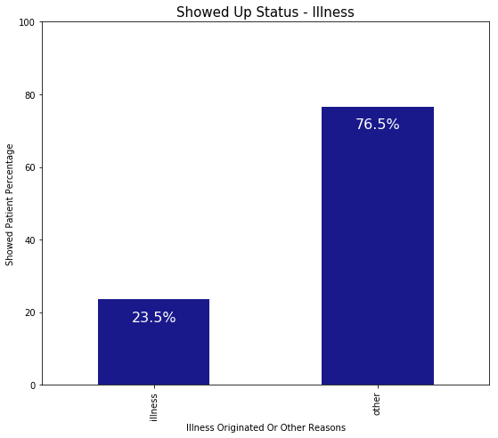

```python
"""As I mentioned in data preparation section, to find out importance of illnesses (in that dataset) for going to an appointment
   illnesses column to be used.

   What i am looking for is that

   1) percentage of people go to an appointment due to diabetes & hipertension & alcoholism (can be thought as sick / ill people)
   2) percentage of people going for an appointment due to reasons of check-up or something else without being sick

   Therefore, in the graph below,

   'Illness' part can be thought as percentage of people who suffer from diabetes or hipertension or alcoholism
   'Other' part can be considered as reasons like check-up / seasonal effect / location effect / sms effect etc which will be investigated in next chapters
   """
""" Below graph will depict us what is the main reason of going for an appointment """

a5 = df_no.groupby("illnesses")["showed"].count()
b5 = round(a5.div(df_no["illnesses"].count())*100,1)
b5.columns=["showed_percentage"]

ax = b5.plot(kind="bar", alpha = 0.9, color= "navy", figsize=(9,7.5))
ax.set_title("Showed Up Status - Illness", fontsize=15)
ax.set_xlabel("Illness Originated Or Other Reasons", fontsize=10)
ax.set_ylabel("Showed Patient Percentage", fontsize=10)
ax.set_ylim(0,100)

# create a list to collect the plt.patches data
totals = []

# find the values and append to list
for i in ax.patches:
    totals.append(i.get_height())

# set individual bar lables using above list
total = sum(totals)

# set individual bar lables using above list
for i in ax.patches:
    # get_x pulls left or right; get_height pushes up or down
    ax.text(i.get_x()+.15, i.get_height()-6, \
            str(round((i.get_height()/total)*100, 2))+'%', fontsize=16,
                color='white')
```

#### Q2.1/A1 Based on the graph above, the main motivation behind going for an appointment is not 'illnesses / being sick'. Therefore we need to investigate other reasons

On the other hand, before skipping to another topic, lets continue to analyse which illness is more crucial!

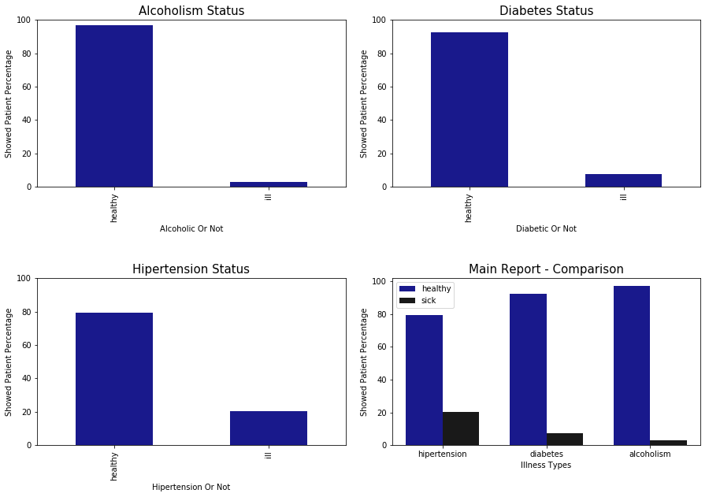

```python
"""with below graphs, we will observe the percentage of patients for every spesified illnesses whose go to the their appointments
   thus will help us to find out which illnesses type is more important for going an appointment"""
"""for example, consider 5% of alcoholic people go to appointment, on the other hand, 10% of diabetics go for an appointment
   therefore it can be easily said that illness of diabetes is more critical than alcoholism for going an appointment"""
"""below graphs contain all percentages for every illnesses & a master chart which includes all illnesses for comparison"""
"""healthy means, patient are not suffered from hipertension, diabetes or alcoholism"""

a = df_no.groupby("hipertension")["showed"].count()
b = round(a.div(df_no["hipertension"].count())*100,1)
b.columns=["showed_percentage"]

a1 = df_no.groupby("diabetes")["showed"].count()
b1 = round(a1.div(df_no["diabetes"].count())*100,1)
b1.columns=["showed_percentage"]
b1

a2 = df_no.groupby("alcoholism")["showed"].count()
b2 = round(a2.div(df_no["alcoholism"].count())*100,1)
b2.columns=["showed_percentage"]
b2

plt.subplot(221)
ax1 = b2.plot(kind="bar", alpha = 0.9, color= "navy", figsize=(9,7.5))
ax1.set_title("Alcoholism Status", fontsize=15)
ax1.set_xlabel("Alcoholic Or Not", fontsize=10)
ax1.set_ylabel("Showed Patient Percentage", fontsize=10)
ax1.set_ylim(0,100)

plt.subplot(222)
ax2 = b1.plot(kind="bar", alpha = 0.9, color= "navy")
ax2.set_title("Diabetes Status", fontsize=15)
ax2.set_ylabel("Showed Patient Percentage", fontsize=10)
ax2.set_xlabel("Diabetic Or Not", fontsize=10)
ax2.set_ylim(0,100)

plt.subplot(223)
ax3 = b.plot(kind="bar", alpha = 0.9, color= "navy")
ax3.set_title("Hipertension Status", fontsize=15)
ax3.set_xlabel("Hipertension Or Not", fontsize=10)
ax3.set_ylabel("Showed Patient Percentage", fontsize=10)
ax3.set_ylim(0,100)

ax4 = plt.subplot(224)
n_groups = 3
healthy = (79.6, 92.6, 97)
sick = (20.4, 7.4, 3)
bar_width = 0.35
index = np.arange(n_groups)
opacity = 0.9
error_config = {'ecolor': '0.3'}

rects1 = ax4.bar(index, healthy, bar_width,
                alpha=opacity, color='navy',
                error_kw=error_config,
                label='healthy')

rects2 = ax4.bar(index + bar_width, sick, bar_width,
                alpha=opacity, color='k',
                error_kw=error_config,
                label='sick')

ax4.set_title('Main Report - Comparison', fontsize=15)
ax4.set_xticks(index + bar_width / 2)
ax4.set_ylabel("Showed Patient Percentage", fontsize=10)
ax4.set_xticklabels(('hipertension', 'diabetes', 'alcoholism'))
ax4.set_xlabel("Illness Types")
plt.tight_layout()
ax4.legend()

plt.subplots_adjust(top=1, bottom=0, left=0.2, right=1.5, hspace=0.55, wspace=0.15)
```

#### Q2.1/A2 Based on graphs above hipertension suffered patients have more tendency to go to doctor

Importance ranking can be done like that hipertension > diabetes > alcoholism

### Question 2.2 - Whare are other the other contributers of going for an appointment ?

#### Q2.2/A1 - Having scholarship, sms receiving status, locational & seasonal impact could be the other contributers of going for an appointment

Lets start with SMS & Scholarship analysis

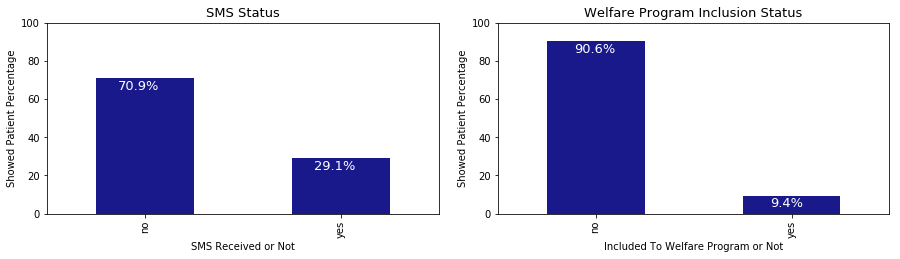

```python
"""For graphs & calculations below, same logic(illnesses section) have done for this section"""
"""with below graphs, we will observe the percentage of patients who received an SMS or included an Scholarship program
   'Yes' bar will show us percentage of patients who received SMS or included to Welfare Program
   If in the SMS Status Graph's 'Yes' bar is higher than Welfare Program Inclusion's 'Yes' bar, which means
   SMS Receive is more important than Scholarship - lets see"""


""" SMS Receive status dataset preperation with percentages"""
a4 = df_no.groupby("sms_received")["showed"].count()
b4 = round(a4.div(df_no["sms_received"].count())*100,1)
b4.columns=["showed_percentage"]

""" Having scholarship dataset preperation with percentages"""
a3 = df_no.groupby("scholarship")["showed"].count()
b3 = round(a3.div(df_no["scholarship"].count())*100,1)
b3.columns=["showed_percentage"]

ax5 = plt.subplot(221)
ax5 = b4.plot(kind="bar", alpha = 0.9, color = "navy", figsize = (9,7.5))
ax5.set_title("SMS Status", fontsize=13)
ax5.set_xlabel("SMS Received or Not", fontsize=10)
ax5.set_ylabel("Showed Patient Percentage", fontsize=10)
ax5.set_ylim(0,100)
totals = []

for i in ax5.patches:
    totals.append(i.get_height())

total = sum(totals)

for i in ax5.patches:
    # get_x pulls left or right; get_height pushes up or down
    ax5.text(i.get_x()+.11, i.get_height()-6, \
            str(round((i.get_height()/total)*100, 2))+'%', fontsize=13,
                color='white')



ax6 = plt.subplot(222)
ax6 = b3.plot(kind="bar", alpha = 0.9, color = "navy")
ax6.set_title("Welfare Program Inclusion Status", fontsize=13)
ax6.set_ylabel("Showed Patient Percentage", fontsize=10)
ax6.set_xlabel("Included To Welfare Program or Not", fontsize=10)
ax6.set_ylim(0,100)
totals = []

for i in ax6.patches:
    totals.append(i.get_height())

total = sum(totals)

for i in ax6.patches:
    ax6.text(i.get_x()+.14, i.get_height()-6, \
            str(round((i.get_height()/total)*100, 2))+'%', fontsize=13,
                color='white')



plt.subplots_adjust(top=0.9, bottom=0, left=0.2, right=1.5, hspace=0.55, wspace=0.15)
```

#### Q2.2/A2 - According to graphs above it can be said that SMS receieve is more critical contributer rather than welfare program involvement

### If we visualise the findings so far , below graphs can be created. (231 & 233)

It can be easily said that SMS or Welfare(Scholarship) Inclusion is more important than being sick to go for an appointment

```python
a5 = df_no.groupby("illnesses")["showed"].count()
b5 = round(a5.div(df_no["illnesses"].count())*100,1)
b5.columns=["showed_percentage"]
b5
```

```
illnesses
illness    23.5
other      76.5
Name: showed, dtype: float64
```

```python
a7 = df_no.groupby("sms_welfare")["showed"].count()
b7 = round(a7.div(df_no["sms_welfare"].count())*100,1)
b7.columns=["showed_percentage"]
b7
```

```
sms_welfare
included        35.9
not_included    64.1
Name: showed, dtype: float64
```

```python
df_ill_sms_wel = {'Contribution' : pd.Series([23.5, 35.9], index=['Illnes', 'SMS&Welfare'])}
df_ill_sms_wel = pd.DataFrame(df_ill_sms_wel)
df_ill_sms_wel
```

|  | Contribution |
| --- | --- |
| Illnes | 23.5 |
| SMS&Welfare | 35.9 |

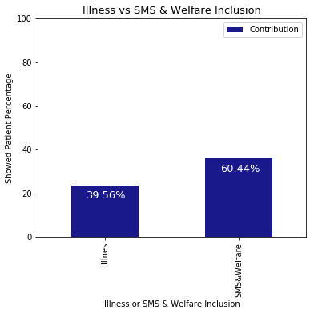

```python
"""Below graph going to show us to find out which one is important 'Being Sick / Ill' or 'SMS Receive & Welfare Involvement'"""
"""Note : Same logic have been implemented to below graph"""
ax7 = df_ill_sms_wel.plot(kind="bar", alpha = 0.9, color="navy", figsize=(6,5))
ax7.set_ylim(0,100)
ax7.set_title("Illness vs SMS & Welfare Inclusion", fontsize=13)
ax7.set_ylabel("Showed Patient Percentage", fontsize=10)
ax7.set_xlabel("Illness or SMS & Welfare Inclusion")
ax7.set_ylim(0,100)

totals = []

for i in ax7.patches:
    totals.append(i.get_height())

total = sum(totals)

for i in ax7.patches:
    ax7.text(i.get_x()+.11, i.get_height()-6, \
            str(round((i.get_height()/total)*100, 2))+'%', fontsize=13,
                color='white')
```

#### Based on graph above SMS & Welfare(Scholarship Involvement) Are Important Than Being Sick

#### If we put all of finding into one graph, below chart can be created (269)

```python
df_all_of_them = {'Healthy/0/NotIncluded' : pd.Series([70, 79, 90, 92, 97], index=["sms receive", 'hipertension', "welfare invl.", 'diabetes', 'alcoholism']), 'Sick/1/Included' : pd.Series([29, 20, 9, 7, 3], index=["sms receive", 'hipertension', "welfare invl.", 'diabetes', 'alcoholism'])}

df_all_of_them = pd.DataFrame(df_all_of_them)
df_all_of_them
```

|  | Healthy/0/NotIncluded | Sick/1/Included |
| --- | --- | --- |
| sms receive | 70 | 29 |
| hipertension | 79 | 20 |
| welfare invl. | 90 | 9 |
| diabetes | 92 | 7 |
| alcoholism | 97 | 3 |

```
Text(0.5,0,'Contributers')
```

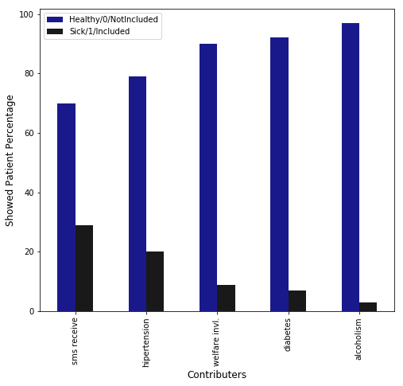

```python
"""now, we are about to create a graph which can easily illustrate the importance levels of items so far"""
colors = ["navy", "k"]
ax8 = df_all_of_them.plot(kind="bar", alpha = 0.9, color =colors, figsize=(8, 7))
ax8.set_ylabel("Showed Patient Percentage", fontsize = 12)
ax8.set_xlabel("Contributers", fontsize = 12)
```

### Q2.2/A2.3 It can be easily said that getting SMS & being a patience with hypertension the most important contributers for going an appointment so far

Because the significant part of patients who went to their appointment 'received SMS' or suffers from hipertension

#### Now, we can investigate if there is any seasonal or locational impact for going an appointment

```python
"""first we need to convert appointment day to pd.datetime and then dt.month
   then convert them to month names like april may"""

df_no["appointment_day_month"] = pd.to_datetime(df_no["appointment_day"]).dt.month
bin_edges = [0, 1, 2, 3, 4, 5, 6, 7, 8, 9, 10, 11, 12]
bin_names = ["January", "February", "March", "April", "May", "June", "July", "August", "September", "October", "November", "December"]
df_no["appointment_day_month_final"] = pd.cut(df_no["appointment_day_month"], bin_edges, labels= bin_names)
df_no.groupby("appointment_day_month_final").count()
```

| appointment_day_month_final | patientid | appointmentid | gender | scheduled_day | appointment_day | age | neighbourhood | scholarship | hipertension | diabetes | alcoholism | sms_received | showed | illnesses | sms_welfare | appointment_day_month |
| --- | --- | --- | --- | --- | --- | --- | --- | --- | --- | --- | --- | --- | --- | --- | --- | --- |
| January | 0 | 0 | 0 | 0 | 0 | 0 | 0 | 0 | 0 | 0 | 0 | 0 | 0 | 0 | 0 | 0 |
| February | 0 | 0 | 0 | 0 | 0 | 0 | 0 | 0 | 0 | 0 | 0 | 0 | 0 | 0 | 0 | 0 |
| March | 0 | 0 | 0 | 0 | 0 | 0 | 0 | 0 | 0 | 0 | 0 | 0 | 0 | 0 | 0 | 0 |
| April | 2602 | 2602 | 2602 | 2602 | 2602 | 2602 | 2602 | 2602 | 2602 | 2602 | 2602 | 2602 | 2602 | 2602 | 2602 | 2602 |
| May | 64037 | 64037 | 64037 | 64037 | 64037 | 64037 | 64037 | 64037 | 64037 | 64037 | 64037 | 64037 | 64037 | 64037 | 64037 | 64037 |
| June | 21569 | 21569 | 21569 | 21569 | 21569 | 21569 | 21569 | 21569 | 21569 | 21569 | 21569 | 21569 | 21569 | 21569 | 21569 | 21569 |
| July | 0 | 0 | 0 | 0 | 0 | 0 | 0 | 0 | 0 | 0 | 0 | 0 | 0 | 0 | 0 | 0 |
| August | 0 | 0 | 0 | 0 | 0 | 0 | 0 | 0 | 0 | 0 | 0 | 0 | 0 | 0 | 0 | 0 |
| September | 0 | 0 | 0 | 0 | 0 | 0 | 0 | 0 | 0 | 0 | 0 | 0 | 0 | 0 | 0 | 0 |
| October | 0 | 0 | 0 | 0 | 0 | 0 | 0 | 0 | 0 | 0 | 0 | 0 | 0 | 0 | 0 | 0 |
| November | 0 | 0 | 0 | 0 | 0 | 0 | 0 | 0 | 0 | 0 | 0 | 0 | 0 | 0 | 0 | 0 |
| December | 0 | 0 | 0 | 0 | 0 | 0 | 0 | 0 | 0 | 0 | 0 | 0 | 0 | 0 | 0 | 0 |

```python
"""Same process - for scheduled day """
df_no["scheduled_day_month"] = pd.to_datetime(df_no["scheduled_day"]).dt.month
bin_edges = [0, 1, 2, 3, 4, 5, 6, 7, 8, 9, 10, 11, 12]
bin_names = ["January", "February", "March", "April", "May", "June", "July", "August", "September","October", "November", "December"]
df_no["scheduled_day_month_final"] = pd.cut(df_no["scheduled_day_month"], bin_edges, labels= bin_names)
df_no.groupby("scheduled_day_month_final").count()
```

| scheduled_day_month_final | patientid | appointmentid | gender | scheduled_day | appointment_day | age | neighbourhood | scholarship | hipertension | diabetes | alcoholism | sms_received | showed | illnesses | sms_welfare | appointment_day_month | appointment_day_month_final | scheduled_day_month |
| --- | --- | --- | --- | --- | --- | --- | --- | --- | --- | --- | --- | --- | --- | --- | --- | --- | --- | --- |
| January | 42 | 42 | 42 | 42 | 42 | 42 | 42 | 42 | 42 | 42 | 42 | 42 | 42 | 42 | 42 | 42 | 42 | 42 |
| February | 199 | 199 | 199 | 199 | 199 | 199 | 199 | 199 | 199 | 199 | 199 | 199 | 199 | 199 | 199 | 199 | 199 | 199 |
| March | 2418 | 2418 | 2418 | 2418 | 2418 | 2418 | 2418 | 2418 | 2418 | 2418 | 2418 | 2418 | 2418 | 2418 | 2418 | 2418 | 2418 | 2418 |
| April | 17490 | 17490 | 17490 | 17490 | 17490 | 17490 | 17490 | 17490 | 17490 | 17490 | 17490 | 17490 | 17490 | 17490 | 17490 | 17490 | 17490 | 17490 |
| May | 55652 | 55652 | 55652 | 55652 | 55652 | 55652 | 55652 | 55652 | 55652 | 55652 | 55652 | 55652 | 55652 | 55652 | 55652 | 55652 | 55652 | 55652 |
| June | 12364 | 12364 | 12364 | 12364 | 12364 | 12364 | 12364 | 12364 | 12364 | 12364 | 12364 | 12364 | 12364 | 12364 | 12364 | 12364 | 12364 | 12364 |
| July | 0 | 0 | 0 | 0 | 0 | 0 | 0 | 0 | 0 | 0 | 0 | 0 | 0 | 0 | 0 | 0 | 0 | 0 |
| August | 0 | 0 | 0 | 0 | 0 | 0 | 0 | 0 | 0 | 0 | 0 | 0 | 0 | 0 | 0 | 0 | 0 | 0 |
| September | 0 | 0 | 0 | 0 | 0 | 0 | 0 | 0 | 0 | 0 | 0 | 0 | 0 | 0 | 0 | 0 | 0 | 0 |
| October | 0 | 0 | 0 | 0 | 0 | 0 | 0 | 0 | 0 | 0 | 0 | 0 | 0 | 0 | 0 | 0 | 0 | 0 |
| November | 1 | 1 | 1 | 1 | 1 | 1 | 1 | 1 | 1 | 1 | 1 | 1 | 1 | 1 | 1 | 1 | 1 | 1 |
| December | 42 | 42 | 42 | 42 | 42 | 42 | 42 | 42 | 42 | 42 | 42 | 42 | 42 | 42 | 42 | 42 | 42 | 42 |

### Q2.2/2.4 According to tables above, it can be easily said that,patients who have appointments in May have more tendency to go to their appointments regardless of their schedule date

#### Lets investigate gender case !

```
Text(0,0.5,'Showed Patient Percentage')
```

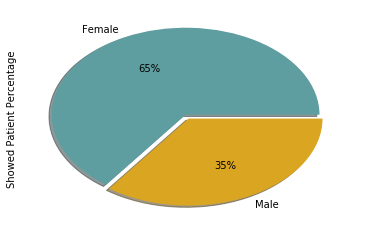

```python
"""lets create a pie chart which shows the percentages of male & females who went to their appointments"""
df_no.groupby("gender")["showed"].count().plot(kind="pie", colors = ["cadetblue", "goldenrod"], labels= ["Female", "Male"], shadow =True, autopct="%.0f%%", explode = [0.05, 0])
plt.ylabel("Showed Patient Percentage", fontsize=10)
```

### Q2.2/A5 Its obvious that female patients give more importance to their appointments :)

#### Lets continue with investigation age status!

```python
df_no["age"].describe()
```

```
count    88208.000000
mean        37.790064
std         23.338878
min         -1.000000
25%         18.000000
50%         38.000000
75%         56.000000
max        115.000000
Name: age, dtype: float64
```

```python
"""-1 aged person can be thought as pregnant ?? - i will consider like that because 1 record is neglectable in 88208"""
```

```
'-1 aged person can be thought as pregnant ?? - i will consider like that because 1 record is neglectable in 88208'
```

```python
"""According to WHO, the lastest age groups are listed below;
   0 - 17 = adolescent
   18 - 65 = young
   66 - 79 = middle age
   80 - ∞ = old

   we can implement the grouping to our dataset in order to better understanding"""
```

```
'According to WHO, the lastest age groups are listed below; \n   0 - 17 = adolescent\n   18 - 65 = young\n   66 - 79 = middle age\n   80 - ∞ = old\n   \n   we can implement the grouping to our dataset in order to better understanding'
```

```python
"""for men & women, age groups can be done like below
   its better to investigate men & women seperately - going to be done afterwards"""
bin_edges = [0, 17, 65, 79, 115]
bin_names = ["adolescent","young", "middle age", "old"]
df_no["age_group"] = pd.cut(df_no["age"], bin_edges, labels= bin_names, include_lowest=True)
X = df_no.groupby("age_group")["showed"].count()
Y = round(X.div(df_no["age_group"].count())*100,1)
X
```

```
age_group
adolescent    21382
young         55590
middle age     8422
old            2813
Name: showed, dtype: int64
```

```python
df_no_deneme = df_no.query("age == 80")
df_no_deneme #check if are borders of groups correct with age == 17, 18, 65, 66, 79, 90, 115 example = 17 should be adolescent, 18 should be young
```

[output not shown]

430 rows × 20 columns

[output not shown]

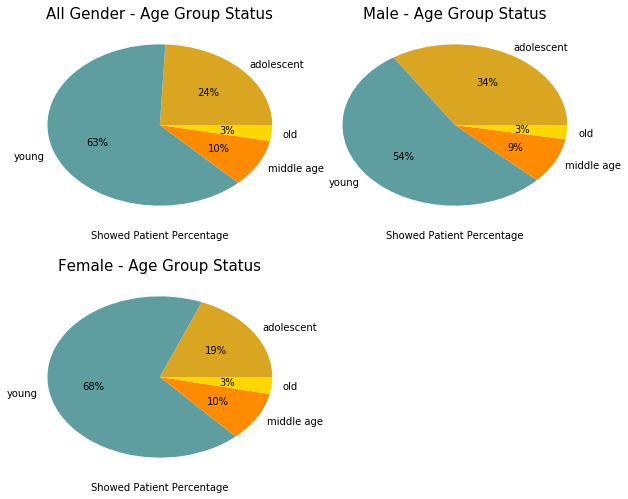

```python
"""Lets create a pie chart for depicting age - grouping and sex breakdown
   to do this, first we need to find out the percentages of them like we did before"""

"""all gender age groups --> finding percentages"""
bin_edges = [0, 17, 65, 79, 115]
bin_names = ["adolescent","young", "middle age", "old"]
df_no["age_group"] = pd.cut(df_no["age"], bin_edges, labels= bin_names, include_lowest=True)
X = df_no.groupby("age_group")["showed"].count()
Y = round(X.div(df_no["age_group"].count())*100,1)

"""men's age groups --> finding percentages"""
df_no_male = df_no.query("gender == 'M'")
bin_edges = [0, 17, 65, 79, 115]
bin_names = ["adolescent","young", "middle age", "old"]
df_no_male["age_group"] = pd.cut(df_no_male["age"], bin_edges, labels= bin_names, include_lowest=True)
M = df_no_male.groupby("age_group")["showed"].count()
N = round(M.div(df_no["age_group"].count())*100,1)

"""women's age groups --> finding percentages"""
df_no_women = df_no.query("gender == 'F'")
bin_edges = [0, 17, 65, 79, 115]
bin_names = ["adolescent","young", "middle age", "old"]
df_no_women["age_group"] = pd.cut(df_no_women["age"], bin_edges, labels= bin_names, include_lowest=True)
F = df_no_women.groupby("age_group")["showed"].count()
G = round(F.div(df_no["age_group"].count())*100,1)

"""Creating pie charts"""
ax1 = plt.subplot(221)
Y.plot(kind="pie", colors =['goldenrod','cadetblue','darkorange','gold'], figsize = (8,7), autopct="%.0f%%")
plt.title("All Gender - Age Group Status", fontsize = 15)
plt.xlabel("Showed Patient Percentage", fontsize=10)
plt.ylabel(".", fontsize=0.0001)
ax2 = plt.subplot(222)
N.plot(kind="pie", colors =['goldenrod','cadetblue','darkorange','gold'], figsize = (8,7), autopct="%.0f%%")
plt.title("Male - Age Group Status", fontsize = 15)
plt.xlabel("Showed Patient Percentage", fontsize=10)
plt.ylabel(".", fontsize=0.0001)
ax3= plt.subplot(223)
G.plot(kind="pie", colors =['goldenrod','cadetblue','darkorange','gold'], figsize = (8,7), autopct="%.0f%%")
plt.title("Female - Age Group Status", fontsize = 15)
plt.xlabel("Showed Patient Percentage", fontsize=10)
plt.ylabel(".", fontsize=0.0001)

plt.subplots_adjust(top=0.9, bottom=0, left=0.2, right=1.2, hspace=0.25, wspace=0.05)
```

### Q2.2/A6 It can be easily said that Young People (between age of 18 - 65) are more interested in going for an appointment

### Q2.2/A7 Female youngs love going for appointments in comparison with men

### lets continue with investigating locations !

```python
# Finding out Top10 Locations
df_no.groupby("neighbourhood")["showed"].count().sort_values(ascending=False).head(10)
```

```
neighbourhood
JARDIM CAMBURI     6252
MARIA ORTIZ        4586
RESISTÊNCIA        3525
JARDIM DA PENHA    3246
SANTA MARTHA       2635
CENTRO             2631
ITARARÉ            2591
TABUAZEIRO         2559
SANTO ANTÔNIO      2262
BONFIM             2223
Name: showed, dtype: int64
```

```python
"""Percentage of Top10  Location Appointment Count"""
A = df_no.groupby("neighbourhood")["showed"].count().sort_values(ascending=False).head(10)
B = round(A.div(df_no["neighbourhood"].count())*100,1)
B
```

```
neighbourhood
JARDIM CAMBURI     7.1
MARIA ORTIZ        5.2
RESISTÊNCIA        4.0
JARDIM DA PENHA    3.7
SANTA MARTHA       3.0
CENTRO             3.0
ITARARÉ            2.9
TABUAZEIRO         2.9
SANTO ANTÔNIO      2.6
BONFIM             2.5
Name: showed, dtype: float64
```

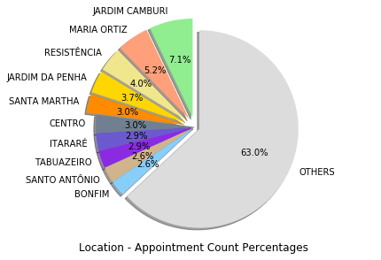

```python
"""Top10 cities pie chart"""
# Pie chart
labels = ['JARDIM CAMBURI', 'MARIA ORTIZ', 'RESISTÊNCIA', 'JARDIM DA PENHA', "SANTA MARTHA", "CENTRO", "ITARARÉ", "TABUAZEIRO", "SANTO ANTÔNIO","BONFIM", "OTHERS"]
sizes = [7.1, 5.2, 4.0, 3.7, 3.0, 3.0, 2.9, 2.9, 2.6, 2.6, 63.1 ]
#colors
colors = ['lightgreen','lightsalmon','khaki','gold', "darkorange", "slategray", "slateblue", "blueviolet", "tan", "lightskyblue", "gainsboro"]
explodes = [0.1, 0.1, 0.1, 0.1, 0.1, 0, 0, 0, 0, 0, 0.05]
fig1, ax1 = plt.subplots()
patches, texts, autotexts = ax1.pie(sizes, colors =colors, labels=labels, autopct ="%1.1f%%", startangle=90, shadow =True, explode = explodes)
for text in texts:
    text.set_color('black')
for autotext in autotexts:
    autotext.set_color('black')
# Equal aspect ratio ensures that pie is drawn as a circle
ax1.axis('equal')
plt.tight_layout()
plt.xlabel("Location - Appointment Count Percentages", fontsize=12)
plt.show()
```

### Q2.2/A6 Top10 Location Covers The Almost %40 Of Total Appointment Count & Living In Jardim Camburi, Maria Ortiz, Resistencia Cities Are Important For Going For Appointment

------------------------0000------------------------------0000---------------------------------------0000---------------------

### The questions which I would like to find an answer are before this project are listed below;

1) What factors are important for us to know in order to predict if a patient will show up for their scheduled appointment?

2) Is Being ill / sick really important ? Or which illness is more critical ?

3) Being sick or SMS receive & welfare incluison - Which one is more critical ?

4) Whare are other the other contributers of going for an appointment ? SMS Receive - Locational Status vb

### Firstly I would like to list the limitations which I have faced & show the ways which I done to handle them !

1) The column names were difficult to use, they had capital letters, white spaces etc. Therefore I put lower cases & '_' instead of capital letters and whitespaces .

2) Schedule day and appointment day had unnecessray letters of 'Z' and 'T' which prevents the datetime usage schedule & appointment day. Therefore I have removed them and converted schedule and appointment day to datetime object.

3) No_Show column had 'Y' data which illustrates patients who did not show up to their appointment. They are not important for us. Therefore its better to delete no_show 'Y' in order not to create confusion

4)Data have not duplicates - it was clean - it was good for not to do additional cleaning process

5)Data have not any null item - again it was good for not to do additional preparing process

### Secondly Lets continue listing the answers of questions above !

##### Answer 1

What factors are important for us to know in order to predict if a patient will show up for their scheduled appointment?

Regarding to my findings above;

a - Illnesses,

b - SMS receive status,

c - Welfare program involvement,

d - Place where patients live

e - Patient's age & sex

f - Appointment day

##### Are important at different levels to predict if a patient will show up to their appointment

### Therefore it is critical to find out their importance levels OR main drivers of every contributer

Consider that 5% alcoholic patients go to their appointment

10% diabetes patients go to their appointment

20% SMS received patients go to their appointment

Therefore it can be easily said that SMS receive status is more critical than being alcoholic.

Dataset have been investigated with logic above & findings have been listed below

##### Answer 2

Is Being ill / sick really important ? Or which illness is more critical ?

Almost 75% of patients showed up to their appointment due to reasons except from illness. Therefore it can be said that being ill/sick is not a critical for going an appointment

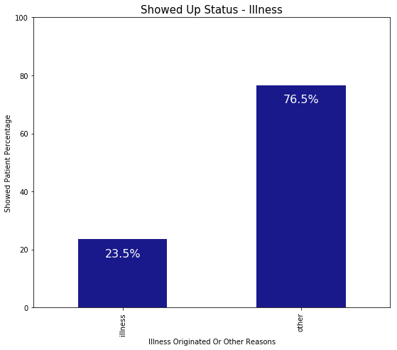

```python
a5 = df_no.groupby("illnesses")["showed"].count()
b5 = round(a5.div(df_no["illnesses"].count())*100,1)
b5.columns=["showed_percentage"]

ax = b5.plot(kind="bar", alpha = 0.9, color= "navy", figsize=(9,7.5))
ax.set_title("Showed Up Status - Illness", fontsize=15)
ax.set_xlabel("Illness Originated Or Other Reasons", fontsize=10)
ax.set_ylabel("Showed Patient Percentage", fontsize=10)
ax.set_ylim(0,100)

# create a list to collect the plt.patches data
totals = []

# find the values and append to list
for i in ax.patches:
    totals.append(i.get_height())

# set individual bar lables using above list
total = sum(totals)

# set individual bar lables using above list
for i in ax.patches:
    # get_x pulls left or right; get_height pushes up or down
    ax.text(i.get_x()+.15, i.get_height()-6, \
            str(round((i.get_height()/total)*100, 2))+'%', fontsize=16,
                color='white')
```

##### Answer 2 - Part 2

The importance level of illnesses can be illustrated like below Hypertension > Diabetes > Alcoholism

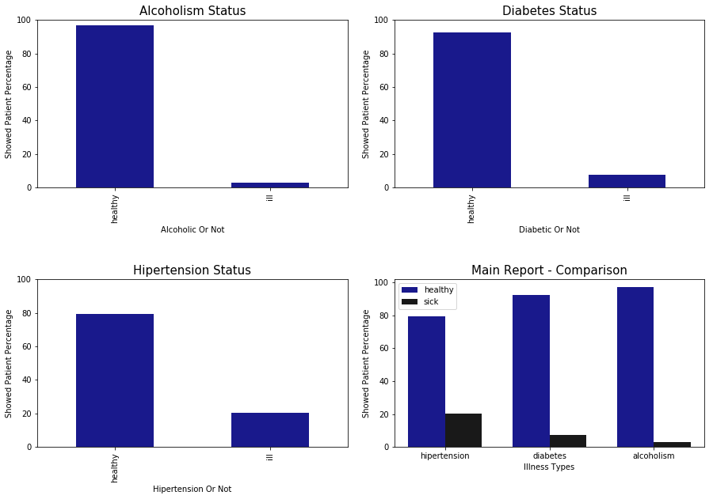

```python
a = df_no.groupby("hipertension")["showed"].count()
b = round(a.div(df_no["hipertension"].count())*100,1)
b.columns=["showed_percentage"]

a1 = df_no.groupby("diabetes")["showed"].count()
b1 = round(a1.div(df_no["diabetes"].count())*100,1)
b1.columns=["showed_percentage"]
b1

a2 = df_no.groupby("alcoholism")["showed"].count()
b2 = round(a2.div(df_no["alcoholism"].count())*100,1)
b2.columns=["showed_percentage"]
b2

plt.subplot(221)
ax1 = b2.plot(kind="bar", alpha = 0.9, color= "navy", figsize=(9,7.5))
ax1.set_title("Alcoholism Status", fontsize=15)
ax1.set_xlabel("Alcoholic Or Not", fontsize=10)
ax1.set_ylabel("Showed Patient Percentage", fontsize=10)
ax1.set_ylim(0,100)

plt.subplot(222)
ax2 = b1.plot(kind="bar", alpha = 0.9, color= "navy")
ax2.set_title("Diabetes Status", fontsize=15)
ax2.set_ylabel("Showed Patient Percentage", fontsize=10)
ax2.set_xlabel("Diabetic Or Not", fontsize=10)
ax2.set_ylim(0,100)

plt.subplot(223)
ax3 = b.plot(kind="bar", alpha = 0.9, color= "navy")
ax3.set_title("Hipertension Status", fontsize=15)
ax3.set_xlabel("Hipertension Or Not", fontsize=10)
ax3.set_ylabel("Showed Patient Percentage", fontsize=10)
ax3.set_ylim(0,100)

ax4 = plt.subplot(224)
n_groups = 3
healthy = (79.6, 92.6, 97)
sick = (20.4, 7.4, 3)
bar_width = 0.35
index = np.arange(n_groups)
opacity = 0.9
error_config = {'ecolor': '0.3'}

rects1 = ax4.bar(index, healthy, bar_width,
                alpha=opacity, color='navy',
                error_kw=error_config,
                label='healthy')

rects2 = ax4.bar(index + bar_width, sick, bar_width,
                alpha=opacity, color='k',
                error_kw=error_config,
                label='sick')

ax4.set_title('Main Report - Comparison', fontsize=15)
ax4.set_xticks(index + bar_width / 2)
ax4.set_ylabel("Showed Patient Percentage", fontsize=10)
ax4.set_xticklabels(('hipertension', 'diabetes', 'alcoholism'))
ax4.set_xlabel("Illness Types")
plt.tight_layout()
ax4.legend()

plt.subplots_adjust(top=1, bottom=0, left=0.2, right=1.5, hspace=0.55, wspace=0.15)
```

#### Answer 3

Being sick or SMS receive & welfare incluison - Which one is more critical ?

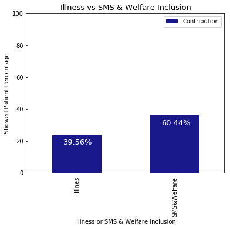

```python
ax7 = df_ill_sms_wel.plot(kind="bar", alpha = 0.9, color="navy", figsize=(6,5))
ax7.set_ylim(0,100)
ax7.set_title("Illness vs SMS & Welfare Inclusion", fontsize=13)
ax7.set_ylabel("Showed Patient Percentage", fontsize=10)
ax7.set_xlabel("Illness or SMS & Welfare Inclusion")
ax7.set_ylim(0,100)

totals = []

for i in ax7.patches:
    totals.append(i.get_height())

total = sum(totals)

for i in ax7.patches:
    ax7.text(i.get_x()+.11, i.get_height()-6, \
            str(round((i.get_height()/total)*100, 2))+'%', fontsize=13,
                color='white')
```

##### Answer 3 - Part 2

Its found that importance levels for going an appointment is ; Getting SMS > Illness of Hypertension > Having Scholarship > Illness of Diabetes > Illness of Alcoholism

```
Text(0.5,0,'Contributers')
```

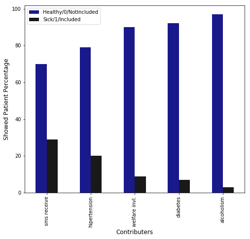

```python
colors = ["navy", "k"]
ax8 = df_all_of_them.plot(kind="bar", alpha = 0.9, color =colors, figsize=(8, 7))
ax8.set_ylabel("Showed Patient Percentage", fontsize = 12)
ax8.set_xlabel("Contributers", fontsize = 12)
```

##### Answer 4

Whare are other the other contributers of going for an appointment ? SMS Receive - Locational Status vb

The other contributers are;

1) Location

2) Sex

3) Age

4) Sesonal

##### Answer 4 - Part 1 - Locations

The main drivers of location are listed below;

1) Jardim Camburi

2) Maria Ortiz

3) Resistencia Cities

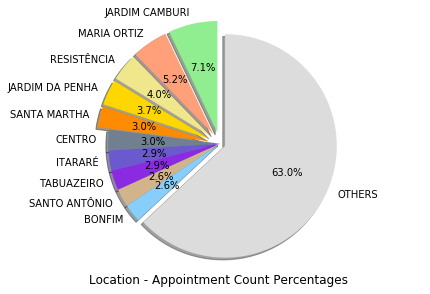

```python
# Pie chart
labels = ['JARDIM CAMBURI', 'MARIA ORTIZ', 'RESISTÊNCIA', 'JARDIM DA PENHA', "SANTA MARTHA", "CENTRO", "ITARARÉ", "TABUAZEIRO", "SANTO ANTÔNIO","BONFIM", "OTHERS"]
sizes = [7.1, 5.2, 4.0, 3.7, 3.0, 3.0, 2.9, 2.9, 2.6, 2.6, 63.1 ]
#colors
colors = ['lightgreen','lightsalmon','khaki','gold', "darkorange", "slategray", "slateblue", "blueviolet", "tan", "lightskyblue", "gainsboro"]
explodes = [0.1, 0.1, 0.1, 0.1, 0.1, 0, 0, 0, 0, 0, 0.05]
fig1, ax1 = plt.subplots()
patches, texts, autotexts = ax1.pie(sizes, colors =colors, labels=labels, autopct ="%1.1f%%", startangle=90, shadow =True, explode = explodes)
for text in texts:
    text.set_color('black')
for autotext in autotexts:
    autotext.set_color('black')
# Equal aspect ratio ensures that pie is drawn as a circle
ax1.axis('equal')
plt.tight_layout()
plt.xlabel("Location - Appointment Count Percentages", fontsize=12)
plt.show()
```

##### Answer 4 - Part 2 - Sex

It can be said that female patients are more stick to their appointments rather than men 65% patient who showed up to their appointments are women

```
Text(0,0.5,'Showed Patient Percentage')
```

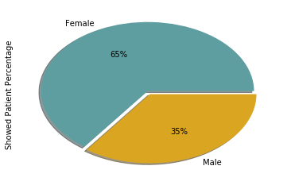

```python
df_no.groupby("gender")["showed"].count().plot(kind="pie", colors = ["cadetblue", "goldenrod"], labels= ["Female", "Male"], shadow =True, autopct="%.0f%%", explode = [0.05, 0])
plt.ylabel("Showed Patient Percentage", fontsize=10)
```

##### Answer 4 - Part 3 - Age

Average of showed up patients age is 37

```python
df_no["age"].describe()
```

```
count    88208.000000
mean        37.790064
std         23.338878
min         -1.000000
25%         18.000000
50%         38.000000
75%         56.000000
max        115.000000
Name: age, dtype: float64
```

If we group the ages regarding to the WHO in order to provide better understanding

0 - 17 = adolescent

18 - 65 = young

66 - 79 = middle age

80 - ∞ = old

##### It can be said that young people have more tendency to go to their appointments (63% show-up patient percentage)

[output not shown]

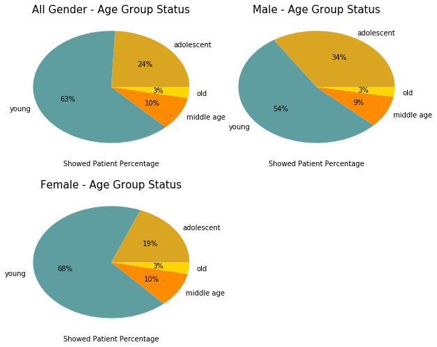

```python
"""all gender age groups --> finding percentages"""
bin_edges = [0, 17, 65, 79, 115]
bin_names = ["adolescent","young", "middle age", "old"]
df_no["age_group"] = pd.cut(df_no["age"], bin_edges, labels= bin_names, include_lowest=True)
X = df_no.groupby("age_group")["showed"].count()
Y = round(X.div(df_no["age_group"].count())*100,1)

"""men's age groups --> finding percentages"""
df_no_male = df_no.query("gender == 'M'")
bin_edges = [0, 17, 65, 79, 115]
bin_names = ["adolescent","young", "middle age", "old"]
df_no_male["age_group"] = pd.cut(df_no_male["age"], bin_edges, labels= bin_names, include_lowest=True)
M = df_no_male.groupby("age_group")["showed"].count()
N = round(M.div(df_no["age_group"].count())*100,1)

"""women's age groups --> finding percentages"""
df_no_women = df_no.query("gender == 'F'")
bin_edges = [0, 17, 65, 79, 115]
bin_names = ["adolescent","young", "middle age", "old"]
df_no_women["age_group"] = pd.cut(df_no_women["age"], bin_edges, labels= bin_names, include_lowest=True)
F = df_no_women.groupby("age_group")["showed"].count()
G = round(F.div(df_no["age_group"].count())*100,1)

"""Creating pie charts"""
ax1 = plt.subplot(221)
Y.plot(kind="pie", colors =['goldenrod','cadetblue','darkorange','gold'], figsize = (8,7), autopct="%.0f%%")
plt.title("All Gender - Age Group Status", fontsize = 15)
plt.xlabel("Showed Patient Percentage", fontsize=10)
plt.ylabel(".", fontsize=0.0001)
ax2 = plt.subplot(222)
N.plot(kind="pie", colors =['goldenrod','cadetblue','darkorange','gold'], figsize = (8,7), autopct="%.0f%%")
plt.title("Male - Age Group Status", fontsize = 15)
plt.xlabel("Showed Patient Percentage", fontsize=10)
plt.ylabel(".", fontsize=0.0001)
ax3= plt.subplot(223)
G.plot(kind="pie", colors =['goldenrod','cadetblue','darkorange','gold'], figsize = (8,7), autopct="%.0f%%")
plt.title("Female - Age Group Status", fontsize = 15)
plt.xlabel("Showed Patient Percentage", fontsize=10)
plt.ylabel(".", fontsize=0.0001)

plt.subplots_adjust(top=0.9, bottom=0, left=0.2, right=1.2, hspace=0.25, wspace=0.05)
```

##### Answer 4 - Part 4 - Seasonal Impact

According to data summary below, most of patients who showed up to their appointments, went to their appointments in May (64037) So appointment day in May is important ++ No seasonal impact have been observed

```python
df_no["appointment_day_month"] = pd.to_datetime(df_no["appointment_day"]).dt.month
bin_edges = [0, 1, 2, 3, 4, 5, 6, 7, 8, 9, 10, 11, 12]
bin_names = ["January", "February", "March", "April", "May", "June", "July", "August", "September", "October", "November", "December"]
df_no["appointment_day_month_final"] = pd.cut(df_no["appointment_day_month"], bin_edges, labels= bin_names)
df_no.groupby("appointment_day_month_final").count()
```

| appointment_day_month_final | patientid | appointmentid | gender | scheduled_day | appointment_day | age | neighbourhood | scholarship | hipertension | diabetes | alcoholism | sms_received | showed | illnesses | sms_welfare | appointment_day_month | scheduled_day_month | scheduled_day_month_final | age_group |
| --- | --- | --- | --- | --- | --- | --- | --- | --- | --- | --- | --- | --- | --- | --- | --- | --- | --- | --- | --- |
| January | 0 | 0 | 0 | 0 | 0 | 0 | 0 | 0 | 0 | 0 | 0 | 0 | 0 | 0 | 0 | 0 | 0 | 0 | 0 |
| February | 0 | 0 | 0 | 0 | 0 | 0 | 0 | 0 | 0 | 0 | 0 | 0 | 0 | 0 | 0 | 0 | 0 | 0 | 0 |
| March | 0 | 0 | 0 | 0 | 0 | 0 | 0 | 0 | 0 | 0 | 0 | 0 | 0 | 0 | 0 | 0 | 0 | 0 | 0 |
| April | 2602 | 2602 | 2602 | 2602 | 2602 | 2602 | 2602 | 2602 | 2602 | 2602 | 2602 | 2602 | 2602 | 2602 | 2602 | 2602 | 2602 | 2602 | 2602 |
| May | 64037 | 64037 | 64037 | 64037 | 64037 | 64037 | 64037 | 64037 | 64037 | 64037 | 64037 | 64037 | 64037 | 64037 | 64037 | 64037 | 64037 | 64037 | 64037 |
| June | 21569 | 21569 | 21569 | 21569 | 21569 | 21569 | 21569 | 21569 | 21569 | 21569 | 21569 | 21569 | 21569 | 21569 | 21569 | 21569 | 21569 | 21569 | 21568 |
| July | 0 | 0 | 0 | 0 | 0 | 0 | 0 | 0 | 0 | 0 | 0 | 0 | 0 | 0 | 0 | 0 | 0 | 0 | 0 |
| August | 0 | 0 | 0 | 0 | 0 | 0 | 0 | 0 | 0 | 0 | 0 | 0 | 0 | 0 | 0 | 0 | 0 | 0 | 0 |
| September | 0 | 0 | 0 | 0 | 0 | 0 | 0 | 0 | 0 | 0 | 0 | 0 | 0 | 0 | 0 | 0 | 0 | 0 | 0 |
| October | 0 | 0 | 0 | 0 | 0 | 0 | 0 | 0 | 0 | 0 | 0 | 0 | 0 | 0 | 0 | 0 | 0 | 0 | 0 |
| November | 0 | 0 | 0 | 0 | 0 | 0 | 0 | 0 | 0 | 0 | 0 | 0 | 0 | 0 | 0 | 0 | 0 | 0 | 0 |
| December | 0 | 0 | 0 | 0 | 0 | 0 | 0 | 0 | 0 | 0 | 0 | 0 | 0 | 0 | 0 | 0 | 0 | 0 | 0 |

### Conclusion

In order to predict if a patient will show up to appointment, below items can be used.

1) Location --> Jardim Camburi, Maria Ortiz, Resistencia Cities

2) Sex ---> Female

3) Age ---> Young people (Avg. Age : 37)

4) Month Of Appointment ---> May

5) Illnesses ---> Hypertension

6) SMS Receive ---> SMS Received (1) / (Y)

7) Scholarship ---> Have Scholarship (1) / (Y)